# Modeling workflow: NLA N2O survey data

#### 3.1.2.3 Bivariate

The graphical check below compared bivariate density contours estimated from the observed data (black lines) to density contours estimated for each of 20 draws from the PPD. The model appeared to do a good job of replicating the bivariate mean, but was poor at representing the overall joint distribution.

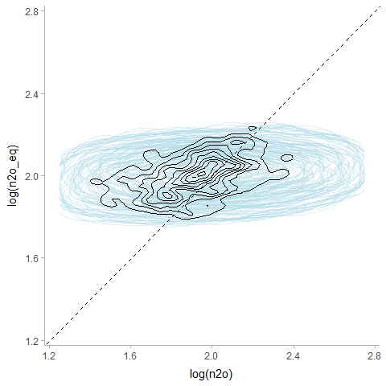

The same bivariate check is shown below for the re-visit data.

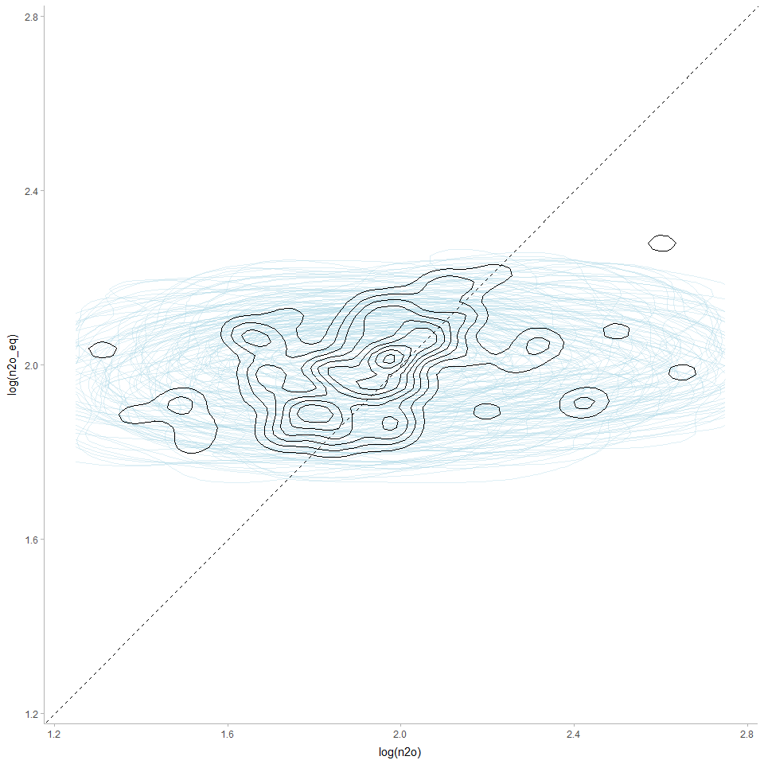

#### 3.1.2.4 Saturation

The graphical PPCs below were aimed at evaluating how well the multivariate model did at representing the observed saturation ratio:

This quantity was estimated as a derived variable by dividing the dissolved N2O PPD by the equilibrium N2O PPD. The proportion of under-saturated lakes in the sample was estimated by summing the number of lakes from each posterior predictive draw wherein the ratio was < 1 and dividing that number by the total number of lakes in the sample, which was 984. Overall, these checks indicated that properly representing the tails of the dissolved N2O and N2O-eq observations would likely be necessary in order to better replicate the observed saturation metrics. The observed proportion of under-saturated lakes was underestimated by more than 10 percentage points, on average.

The top left panel, below, is a density plot of the observed saturation ratio (black line) compared to an estimate using 50 draws from the derived PPD (blue lines). The top right panel shows the observed proportion of under-saturated lakes compared to a model estimate based on 1000 draws from the PPD. The left middle panel shows the mean *vs.* standard deviation of the saturation ratio for the observed data compared to the same estimates for 500 draws from the PPD. The right middle panel shows the max *vs.* min for the sample compared to 500 draws from the PPD. Finally, the bottom left panel shows the observed *vs.* average predicted saturation ratio for all 984 lakes sampled in the dataset.

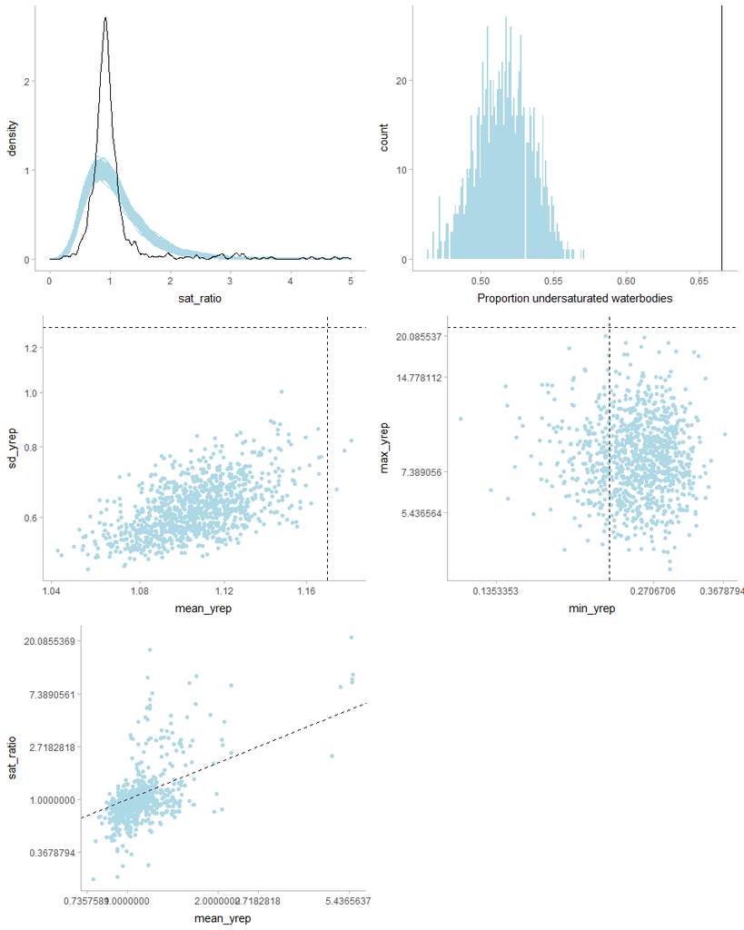

The same PPCs are shown below for the revisit data. These checks indicated that the model did a similarly underwhelming job of replicating the re-visit data.

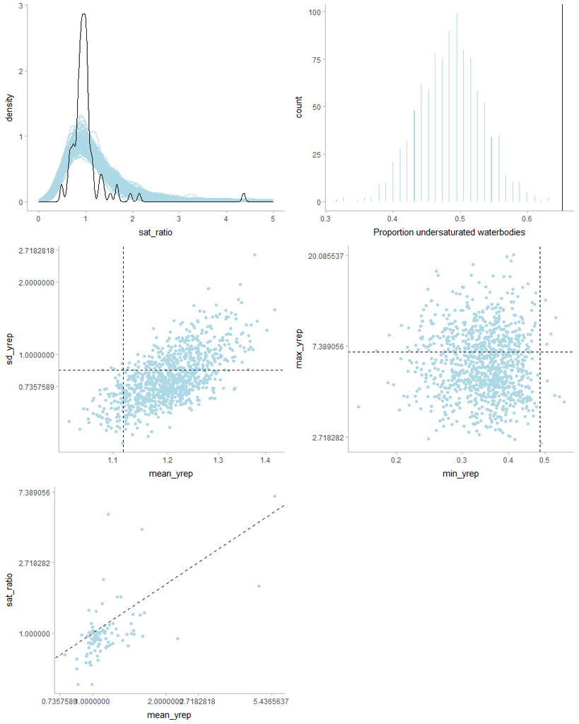

#### 3.1.2.5 R-square

Below, the Bayesian values are reported for each response in the model.

```
##          Estimate Est.Error  Q2.5 Q97.5
## R2logn2o    0.247     0.031 0.187 0.309

##            Estimate Est.Error  Q2.5 Q97.5
## R2logn2oeq    0.377     0.025 0.328 0.425
```

The were also estimated for the re-visit data.

```
##          Estimate Est.Error  Q2.5 Q97.5
## R2logn2o    0.413      0.04 0.331 0.489

##            Estimate Est.Error  Q2.5 Q97.5
## R2logn2oeq    0.322     0.026 0.271 0.374
```

## 3.2 Model 2

In an attempt to better fit the observed data, the next model included a distributional sub-model that allowed for heterogeneous variances. The distributional terms for both N2O responses were each fit as a function of the survey design structure. The same structure as for the models for the submodels for the mean component before.

```r
bf_n2o <- bf(log(n2o) ~ 1 +
               (1 | a | WSA9) +
               (1 | b | WSA9:state) +
               (1 | c | WSA9:state:size_cat),
             sigma ~ 1 +
               (1 | WSA9) +
               (1 | WSA9:state) +
               (1 | WSA9:state:size_cat),
             family = gaussian())

bf_n2oeq <- bf(log(n2o_eq) ~ 1 +
                 (1 | a | WSA9) +
                 (1 | b | WSA9:state) +
                 (1 | c | WSA9:state:size_cat),
             sigma ~ 1 +
               (1 | WSA9) +
               (1 | WSA9:state) +
               (1 | WSA9:state:size_cat),
             family = gaussian())

priors <- c(
  prior(normal(2, 1), class = "Intercept", resp = "logn2o"),
  prior(exponential(2), class = "sd", resp = "logn2o"),
  prior(normal(-1, 2), class = "Intercept", dpar = "sigma", resp = "logn2o"),
  prior(exponential(2), class = "sd", dpar = "sigma", resp = "logn2o"),
  prior(normal(2, 1), class = "Intercept", resp = "logn2oeq"),
  prior(exponential(2), class = "sd", resp = "logn2oeq"),
  prior(normal(-1, 2), class = "Intercept", dpar = "sigma", resp = "logn2oeq"),
  prior(exponential(2), class = "sd", dpar = "sigma", resp = "logn2oeq"),

  prior(lkj(2), class = "rescor"),
  prior(lkj(2), class = "cor")
  )

n2o_mod2 <- brm(bf_n2o + bf_n2oeq + set_rescor(rescor = TRUE),
                data = df_model,
                prior = priors,
  control = list(adapt_delta = 0.975, max_treedepth = 12),
  #sample_prior = "only",
  save_pars = save_pars(all = TRUE),
  seed = 84512,
  chains=4,
  iter=5000,
  cores=4)

save(n2o_mod2, file = "C:/Users/rmartin/OneDrive - Environmental Protection Agency (EPA)/Documents/AE_Reservoirs/DissolvedGasNla/modelFiles/n2o_mod2.rda")
```

### 3.2.1 Summarize fit

The summaries of the estimated parameters and key HMC convergence diagnostics for the fitted model are printed below.

```
##  Family: MV(gaussian, gaussian)
##   Links: mu = identity; sigma = log
##          mu = identity; sigma = log
## Formula: log(n2o) ~ 1 + (1 | a | WSA9) + (1 | b | WSA9:state) + (1 | c | WSA9:state:size_cat)
##          sigma ~ 1 + (1 | WSA9) + (1 | WSA9:state) + (1 | WSA9:state:size_cat)
##          log(n2o_eq) ~ 1 + (1 | a | WSA9) + (1 | b | WSA9:state) + (1 | c | WSA9:state:size_cat)
##          sigma ~ 1 + (1 | WSA9) + (1 | WSA9:state) + (1 | WSA9:state:size_cat)
##    Data: df_model (Number of observations: 984)
##   Draws: 4 chains, each with iter = 5000; warmup = 2500; thin = 1;
##          total post-warmup draws = 10000
##
## Priors:
## Intercept_logn2o ~ normal(2, 1)
## Intercept_logn2o_sigma ~ normal(-1, 2)
## Intercept_logn2oeq ~ normal(2, 1)
## Intercept_logn2oeq_sigma ~ normal(-1, 2)
## L ~ lkj_corr_cholesky(2)
## Lrescor ~ lkj_corr_cholesky(2)
## <lower=0> sd_logn2o ~ exponential(2)
## <lower=0> sd_logn2o_sigma ~ exponential(2)
## <lower=0> sd_logn2oeq ~ exponential(2)
## <lower=0> sd_logn2oeq_sigma ~ exponential(2)
##
## Multilevel Hyperparameters:
## ~WSA9 (Number of levels: 9)
##                                          Estimate Est.Error l-95% CI u-95% CI
## sd(logn2o_Intercept)                         0.06      0.03     0.02     0.12
## sd(logn2oeq_Intercept)                       0.05      0.02     0.03     0.09
## sd(sigma_logn2o_Intercept)                   0.22      0.12     0.02     0.50
## sd(sigma_logn2oeq_Intercept)                 0.16      0.08     0.04     0.34
## cor(logn2o_Intercept,logn2oeq_Intercept)     0.57      0.30    -0.18     0.95
##                                          Rhat Bulk_ESS Tail_ESS
## sd(logn2o_Intercept)                     1.00     2247     1772
## sd(logn2oeq_Intercept)                   1.00     3423     4761
## sd(sigma_logn2o_Intercept)               1.00     1892     3094
## sd(sigma_logn2oeq_Intercept)             1.00     2413     1991
## cor(logn2o_Intercept,logn2oeq_Intercept) 1.00     2696     3538
##
## ~WSA9:state (Number of levels: 96)
##                                          Estimate Est.Error l-95% CI u-95% CI
```

[output cut: 32 more lines]

```
##                          Tail_ESS
## logn2o_Intercept             4462
## sigma_logn2o_Intercept       5077
## logn2oeq_Intercept           4145
## sigma_logn2oeq_Intercept     4848
##
## Residual Correlations:
##                         Estimate Est.Error l-95% CI u-95% CI Rhat Bulk_ESS
## rescor(logn2o,logn2oeq)     0.36      0.03     0.29     0.43 1.00     6474
##                         Tail_ESS
## rescor(logn2o,logn2oeq)     7733
##
## Draws were sampled using sampling(NUTS). For each parameter, Bulk_ESS
## and Tail_ESS are effective sample size measures, and Rhat is the potential
## scale reduction factor on split chains (at convergence, Rhat = 1).
```

### 3.2.2 Model checks

Below the same PPCs were performed as with the initial model (see above for more details on each panel). Though the checks below suggested some improvement in replicating the tails of the observed data, the overall fit again suggested room for improvement.

##### 3.2.2.0.1 Dissolved N2O

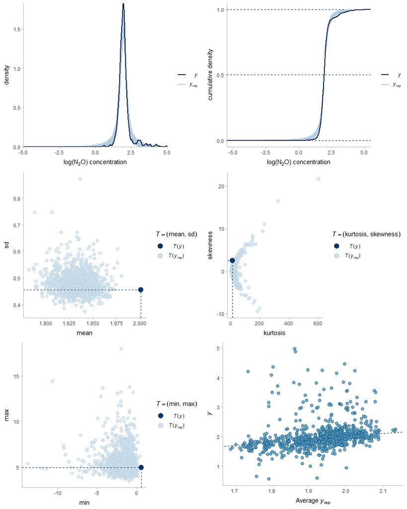

The same check is below for the 95 re-visit sites.

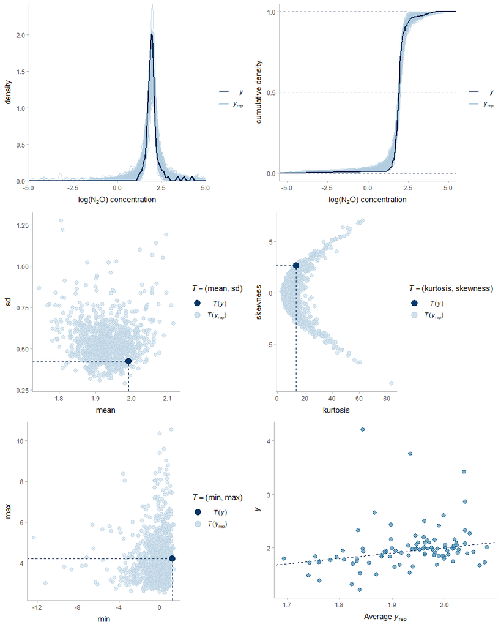

#### 3.2.2.1 Equilibrium N2O

The checks below suggested that this model offered little improvement upon the initial model for equilibrium N2O.

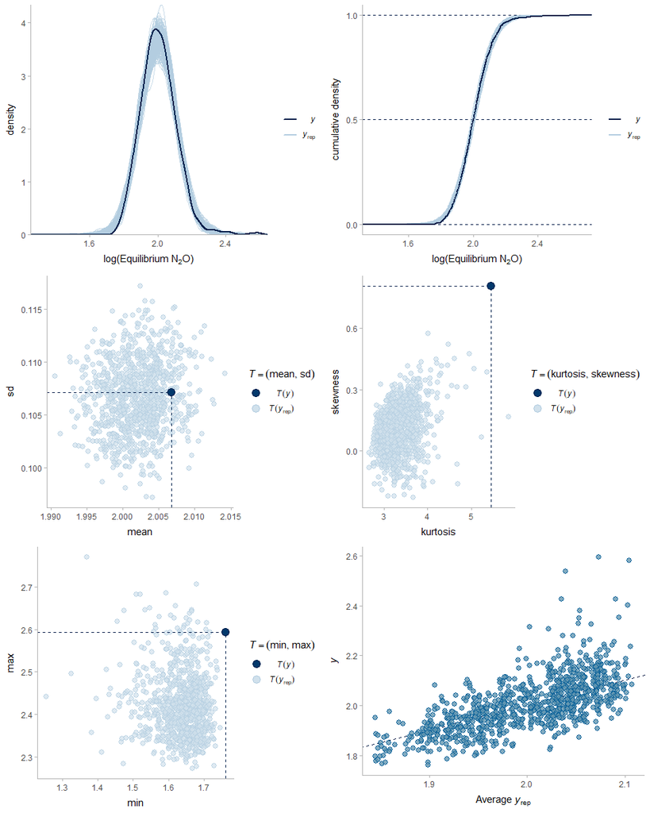

The same check with the re-visit data is below.

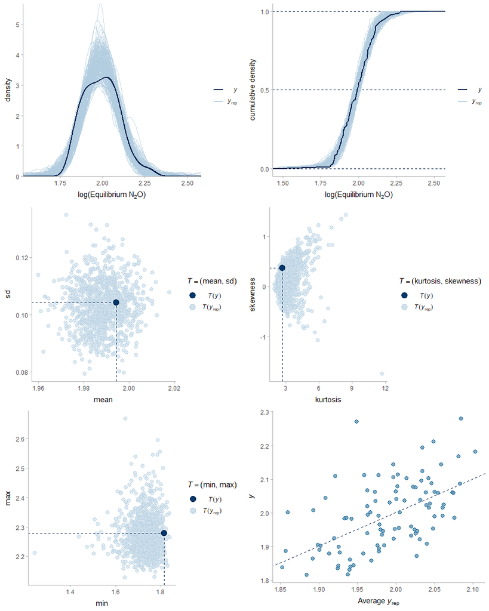

#### 3.2.2.2 Bivariate

This check perhaps suggested an improvement with regard to replicating the joint density. However, the predictions were still clearly over-dispersed relative to the observations.

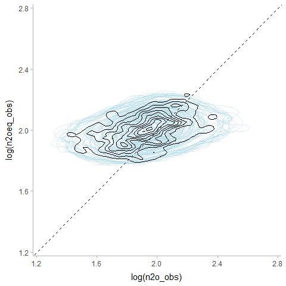

The same check with the re-visit data is below.

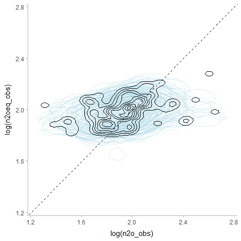

#### 3.2.2.3 Saturation

The PPCs for the saturation metrics below indicated that including the distributional models was perhaps an improvement on the initial model in some aspects; in particular, the bias in the predicted proportion of under-saturated lakes was substantially decreased. However, there appeared to still be issues in replicating the tails as well as issues with central tendency.

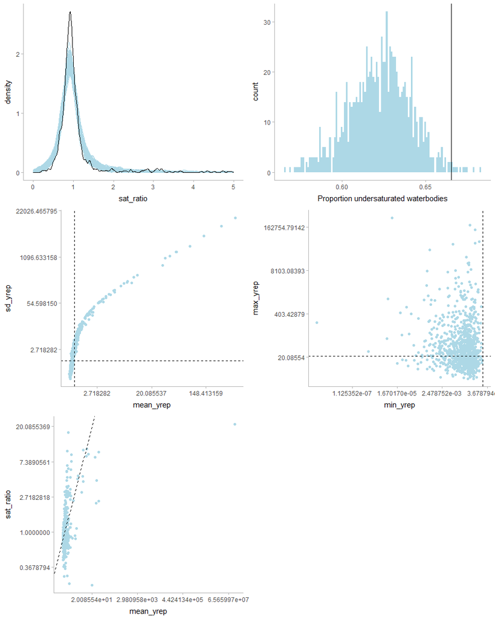

The check for the revisit data is below.

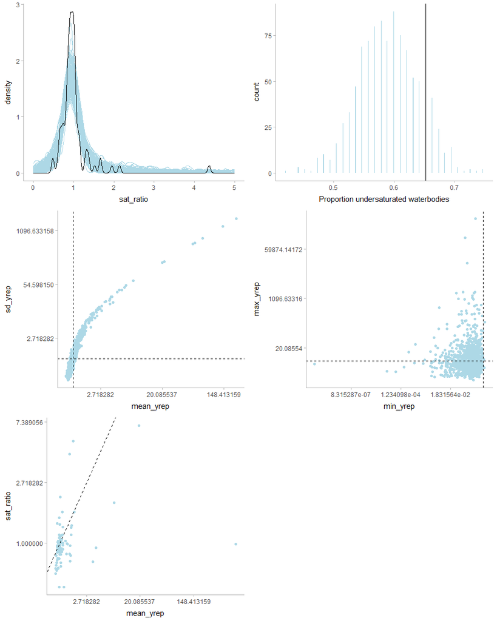

#### 3.2.2.4 R-square

Relative to model 1, there was a substantial decrease in the estimate for the dissolved N2O component of this model. The estimate for the equilibrium N2O-eq component was similar to model 1.

```
##          Estimate Est.Error  Q2.5 Q97.5
## R2logn2o    0.056     0.009 0.038 0.075

##            Estimate Est.Error  Q2.5 Q97.5
## R2logn2oeq    0.379     0.022 0.335 0.421
```

And for the re-visit data:

```
##          Estimate Est.Error  Q2.5 Q97.5
## R2logn2o    0.071     0.014 0.046   0.1

##            Estimate Est.Error  Q2.5 Q97.5
## R2logn2oeq    0.323     0.023 0.278 0.369
```

## 3.3 Model 3

In the next model, the categorical version of the NO3 covariate and a surface temperature covariate were included to try to improve the fit. The ordinal NO3 variable was used as a monotonic, ordinal effect and only in the dissolved N2O component of the model. For the equlibrium N2O component, surface temperature and log-transformed elevation were used, along with their interaction. The model also retained the same distributional specifications included in model 2 above.

```r
bf_n2o <- bf(log(n2o) ~ mo(no3_cat) +
               surftemp +
               (mo(no3_cat) | a | WSA9) +
               (mo(no3_cat) | b | WSA9:state) +
               (1 | c | WSA9:state:size_cat),
             sigma ~ 1 +
               (1 | WSA9) +
               (1 | WSA9:state) +
               (1 | WSA9:state:size_cat),
             family = gaussian())

bf_n2oeq <- bf(log(n2o_eq) ~ surftemp +
                 log_elev +
                 surftemp:log_elev +
                 (1 | a | WSA9) +
                 (1 | b | WSA9:state) +
                 (1 | c | WSA9:state:size_cat),
             sigma ~ 1 +
               (1 | WSA9) +
               (1 | WSA9:state) +
               (1 | WSA9:state:size_cat),
             family = gaussian())

priors <- c(
  prior(normal(2, 1), class = "Intercept", resp = "logn2o"),
  prior(normal(0, 1), class = "b", resp = "logn2o"),
  prior(exponential(2), class = "sd", resp = "logn2o"),
  prior(normal(-1, 2), class = "Intercept", dpar = "sigma", resp = "logn2o"),
  prior(exponential(2), class = "sd", dpar = "sigma", resp = "logn2o"),
  prior(normal(2, 1), class = "Intercept", resp = "logn2oeq"),
  prior(normal(0, 1), class = "b", resp = "logn2oeq"),
  prior(exponential(2), class = "sd", resp = "logn2oeq"),
  prior(normal(-1, 2), class = "Intercept", dpar = "sigma", resp = "logn2oeq"),
  prior(exponential(2), class = "sd", dpar = "sigma", resp = "logn2oeq"),

  prior(lkj(2), class = "rescor"),
  prior(lkj(2), class = "cor")
  )

n2o_mod3 <- brm(bf_n2o + bf_n2oeq + set_rescor(rescor = TRUE),
                data = df_model,
                prior = priors,
  control = list(adapt_delta = 0.975, max_treedepth = 12),
  #sample_prior = "only",
  save_pars = save_pars(all = TRUE),
  seed = 98456,
  chains=4,
  iter=5000,
  cores=4)

save(n2o_mod3, file = "C:/Users/rmartin/OneDrive - Environmental Protection Agency (EPA)/Documents/AE_Reservoirs/DissolvedGasNla/modelFiles/n2o_mod3.rda")
```

### 3.3.1 Summarize fit

The fitted parameters and MCMC diagnostics are below.

```
##  Family: MV(gaussian, gaussian)
##   Links: mu = identity; sigma = log
##          mu = identity; sigma = log
## Formula: log(n2o) ~ mo(no3_cat) + surftemp + (mo(no3_cat) | a | WSA9) + (mo(no3_cat) | b | WSA9:state) + (1 | c | WSA9:state:size_cat)
##          sigma ~ 1 + (1 | WSA9) + (1 | WSA9:state) + (1 | WSA9:state:size_cat)
##          log(n2o_eq) ~ surftemp + log_elev + surftemp:log_elev + (1 | a | WSA9) + (1 | b | WSA9:state) + (1 | c | WSA9:state:size_cat)
##          sigma ~ 1 + (1 | WSA9) + (1 | WSA9:state) + (1 | WSA9:state:size_cat)
##    Data: df_model (Number of observations: 984)
##   Draws: 4 chains, each with iter = 5000; warmup = 2500; thin = 1;
##          total post-warmup draws = 10000
##
## Priors:
## b_logn2o ~ normal(0, 1)
## b_logn2oeq ~ normal(0, 1)
## Intercept_logn2o ~ normal(2, 1)
## Intercept_logn2o_sigma ~ normal(-1, 2)
## Intercept_logn2oeq ~ normal(2, 1)
## Intercept_logn2oeq_sigma ~ normal(-1, 2)
## L ~ lkj_corr_cholesky(2)
## Lrescor ~ lkj_corr_cholesky(2)
## <lower=0> sd_logn2o ~ exponential(2)
## <lower=0> sd_logn2o_sigma ~ exponential(2)
## <lower=0> sd_logn2oeq ~ exponential(2)
## <lower=0> sd_logn2oeq_sigma ~ exponential(2)
## simo_logn2o_mono3_cat1 ~ dirichlet(1)
##
## Multilevel Hyperparameters:
## ~WSA9 (Number of levels: 9)
##                                          Estimate Est.Error l-95% CI u-95% CI
## sd(logn2o_Intercept)                         0.05      0.02     0.02     0.10
## sd(logn2o_mono3_cat)                         0.14      0.05     0.06     0.26
## sd(logn2oeq_Intercept)                       0.04      0.01     0.02     0.07
## sd(sigma_logn2o_Intercept)                   0.12      0.08     0.01     0.31
## sd(sigma_logn2oeq_Intercept)                 0.36      0.11     0.19     0.64
## cor(logn2o_Intercept,logn2o_mono3_cat)      -0.14      0.33    -0.72     0.53
## cor(logn2o_Intercept,logn2oeq_Intercept)     0.36      0.29    -0.28     0.83
## cor(logn2o_mono3_cat,logn2oeq_Intercept)     0.37      0.29    -0.26     0.82
##                                          Rhat Bulk_ESS Tail_ESS
## sd(logn2o_Intercept)                     1.00     4265     3917
## sd(logn2o_mono3_cat)                     1.00     4747     5482
```

[output cut: 69 more lines]

```
##                      Tail_ESS
## logn2o_mono3_cat1[1]     5409
## logn2o_mono3_cat1[2]     5251
## logn2o_mono3_cat1[3]     4649
## logn2o_mono3_cat1[4]     4251
##
## Residual Correlations:
##                         Estimate Est.Error l-95% CI u-95% CI Rhat Bulk_ESS
## rescor(logn2o,logn2oeq)     0.15      0.04     0.07     0.23 1.00    11381
##                         Tail_ESS
## rescor(logn2o,logn2oeq)     7610
##
## Draws were sampled using sampling(NUTS). For each parameter, Bulk_ESS
## and Tail_ESS are effective sample size measures, and Rhat is the potential
## scale reduction factor on split chains (at convergence, Rhat = 1).
```

### 3.3.2 Model checks

#### 3.3.2.1 Dissolved N2O

The PPCs below indicated a better fit compared to the previous models. The central tendency and tail behavior looked to be reasonably replicated by comparison. However, the observed *vs.* predicted plot suggested that larger N2O observations were likely being systematically underestimated.

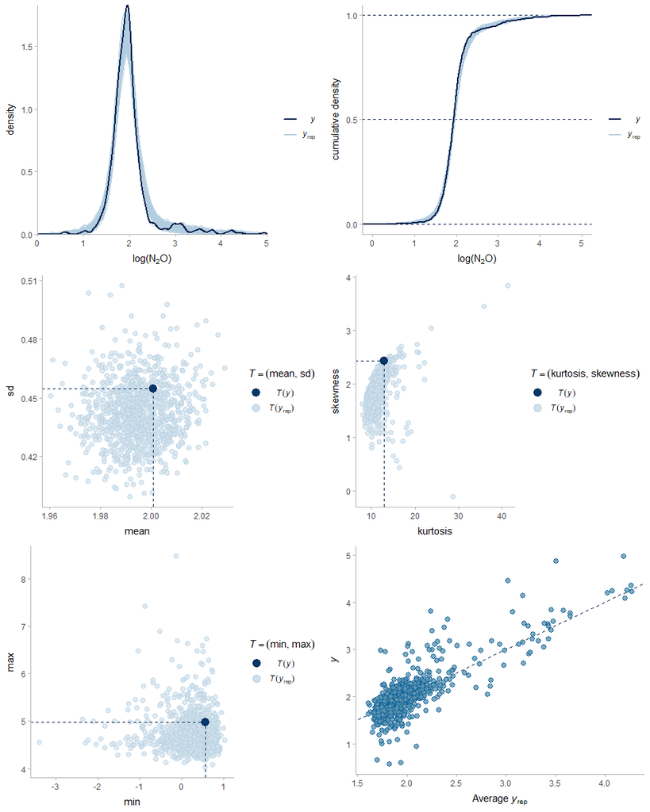

Below are the same PPCs for the second-visit data.

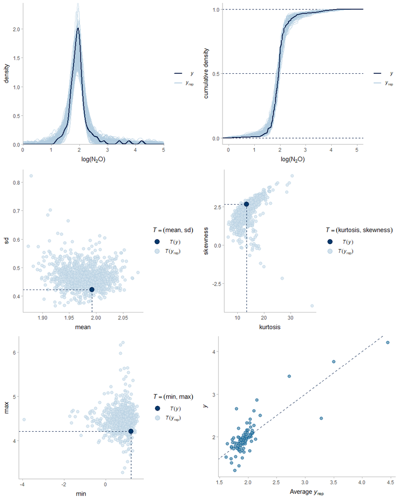

#### 3.3.2.2 Equilibrium N2O

The PPCs below indicated that this model appeared to be an improvement for equilibrium N2O as well. However, some checks (e.g., skewness) suggested some room for additional improvement.

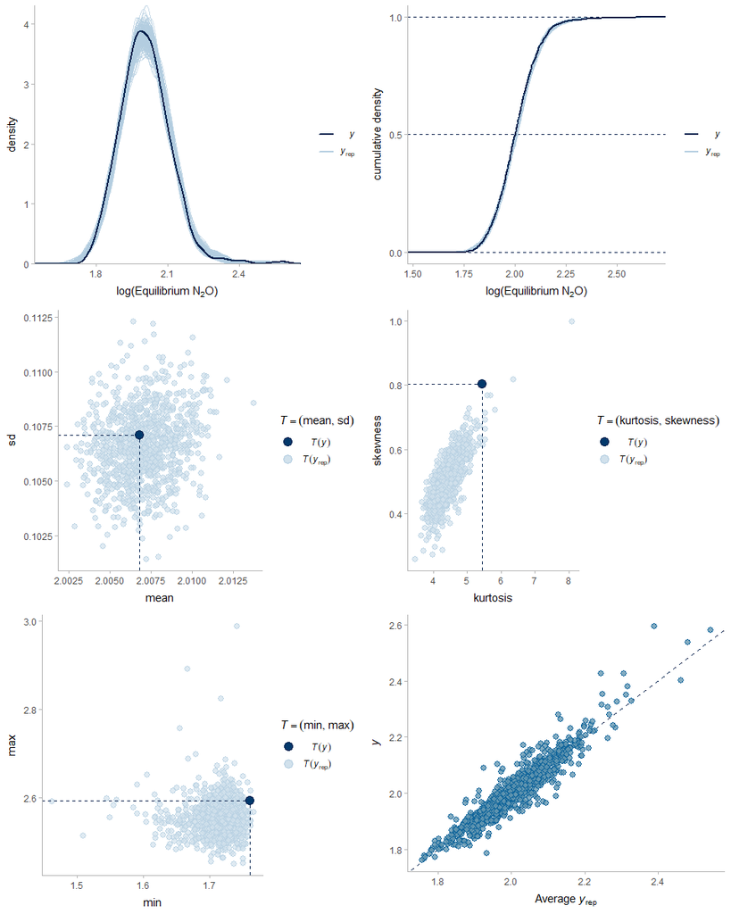

Checks for the 2nd visit data are below.

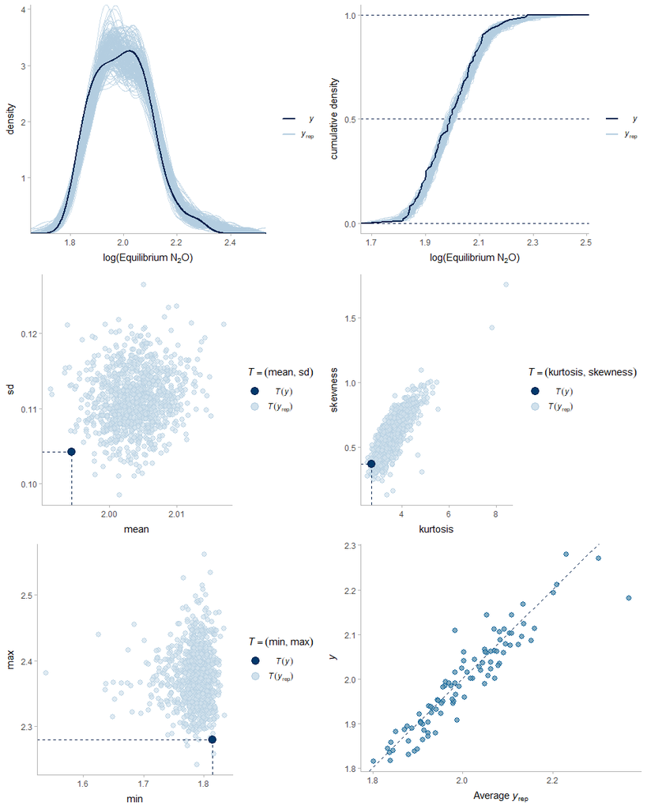

#### 3.3.2.3 Bivariate

The check for the joint distribution below also suggested an improvement upon the previous models.

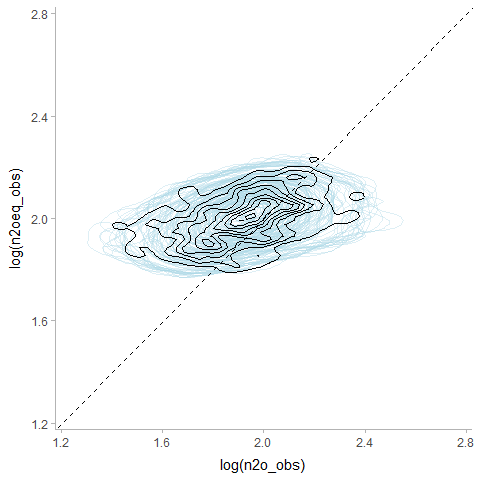

The same check below for the second-visit sites.

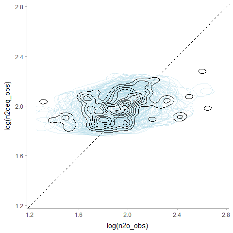

#### 3.3.2.4 Saturation

This model looked to be an improvement with regard to the PPCs for the saturation metrics. However, the proportion of under-saturated lakes remained biased low and other checks indicated that further improvements would be ideal.

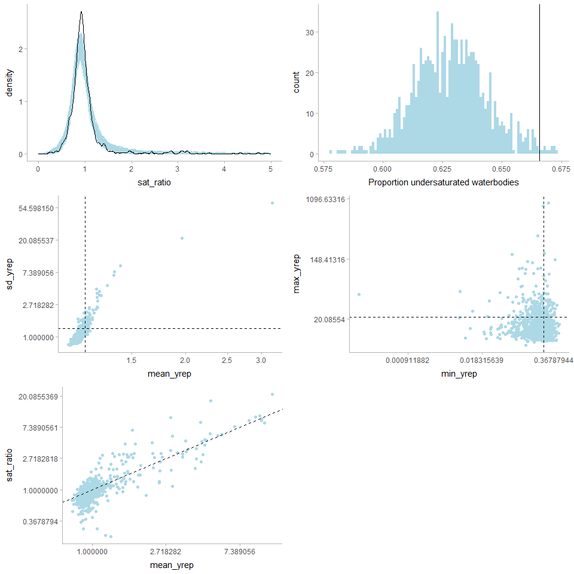

The same check for the second-visit sites are next.

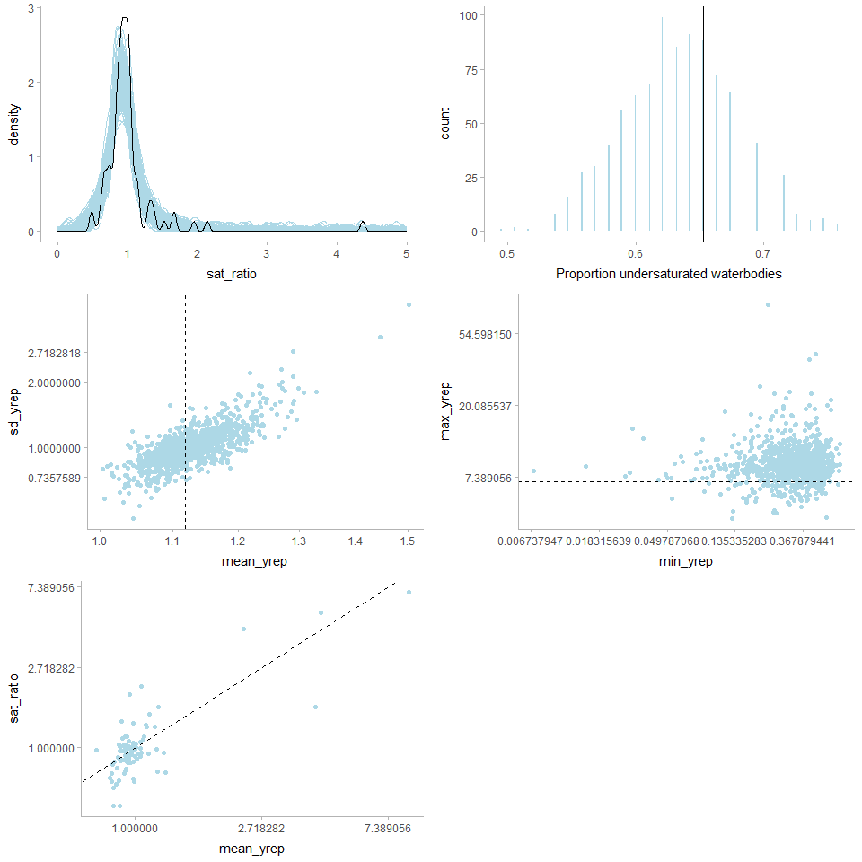

#### 3.3.2.5 R-square

The estimates for this model are below and suggested substantial improvements over the previous models.

```
##          Estimate Est.Error  Q2.5 Q97.5
## R2logn2o    0.626     0.017 0.591  0.66

##            Estimate Est.Error Q2.5 Q97.5
## R2logn2oeq    0.879     0.004 0.87 0.886
```

Next, for the 2nd visit sites.

```
##          Estimate Est.Error  Q2.5 Q97.5
## R2logn2o    0.686     0.026 0.625 0.728

##            Estimate Est.Error  Q2.5 Q97.5
## R2logn2oeq    0.875     0.006 0.862 0.887
```

### 3.3.3 Covariate effects

Below are plots illustrating the modeled effects of covariates on both N2O and equilibrium N2O.

#### 3.3.3.1 Dissolved N2O

The conditional effects plots below for dissolved N2O illustrated a positive, monotonic, and non-linear relationship with NO3; and a negative, linear relationship with surface temperature.

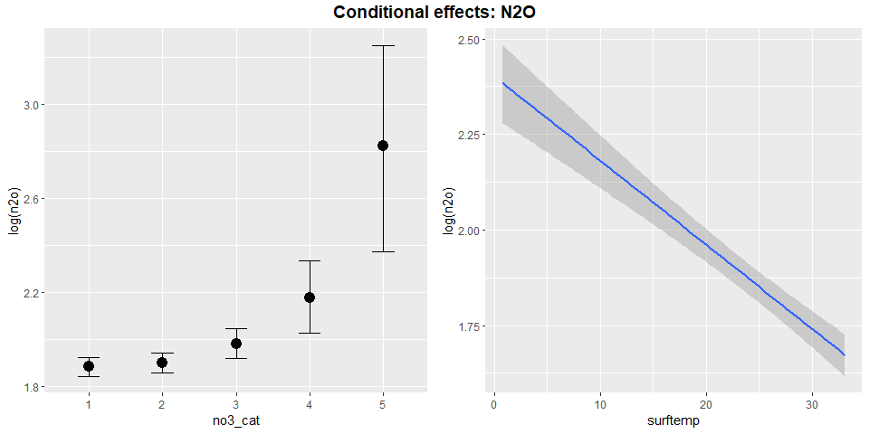

#### 3.3.3.2 Equilibrium N2O

The modeled effects for the equilibrium N2O component illustrated a negative relationship with both predictors and an interaction such that the surface temperature effect became slightly steeper at lower elevations.

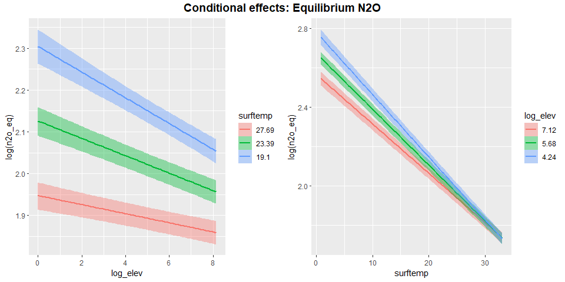

## 3.4 Model 4

In the next model, covariate terms were also included in the components of both models in order to try to better capture remaining heterogeneity in the variances of both N2O and N2O-eq.

```r
bf_n2o <- bf(log(n2o) ~ mo(no3_cat) +
               surftemp +
               (mo(no3_cat) | a | WSA9) +
               (mo(no3_cat) | b | WSA9:state) +
               (1 | c | WSA9:state:size_cat),
             sigma ~ mo(no3_cat) +
               surftemp +
               (1 | WSA9) +
               (1 | WSA9:state) +
               (1 | WSA9:state:size_cat),
             family = gaussian())

bf_n2oeq <- bf(log(n2o_eq) ~ surftemp +
                 log_elev +
                 surftemp:log_elev +
                 (1 | a | WSA9) +
                 (1 | b | WSA9:state) +
                 (1 | c | WSA9:state:size_cat),
             sigma ~ surftemp +
               log_elev +
               (1 | WSA9) +
               (1 | WSA9:state) +
               (1 | WSA9:state:size_cat),
             family = gaussian())

priors <- c(
  prior(normal(2, 1), class = "Intercept", resp = "logn2o"),
  prior(normal(0, 1), class = "b", resp = "logn2o"),
  prior(exponential(2), class = "sd", resp = "logn2o"),
  prior(normal(-1, 2), class = "Intercept", dpar = "sigma", resp = "logn2o"),
  prior(normal(0, 1), class = "b", dpar = "sigma", resp = "logn2o"),
  prior(exponential(2), class = "sd", dpar = "sigma", resp = "logn2o"),
  prior(normal(2, 1), class = "Intercept", resp = "logn2oeq"),
  prior(normal(0, 1), class = "b", resp = "logn2oeq"),
  prior(exponential(2), class = "sd", resp = "logn2oeq"),
  prior(normal(-1, 2), class = "Intercept", dpar = "sigma", resp = "logn2oeq"),
  prior(normal(0, 1), class = "b", dpar = "sigma", resp = "logn2oeq"),
  prior(exponential(2), class = "sd", dpar = "sigma", resp = "logn2oeq"),

  prior(lkj(2), class = "rescor"),
  prior(lkj(2), class = "cor")
  )

n2o_mod4 <- brm(bf_n2o + bf_n2oeq + set_rescor(rescor = TRUE),
                data = df_model,
                prior = priors,
  control = list(adapt_delta = 0.975, max_treedepth = 12),
  #sample_prior = "only",
  save_pars = save_pars(all = TRUE),
  seed = 15851,
  chains=4,
  iter=5000,
  cores=4)

save(n2o_mod4, file = "C:/Users/rmartin/OneDrive - Environmental Protection Agency (EPA)/Documents/AE_Reservoirs/DissolvedGasNla/modelFiles/n2o_mod4.rda")
```

### 3.4.1 Summarize fit

Below is a summary of the fitted parameters along with some convergence diagnostics.

```
##  Family: MV(gaussian, gaussian)
##   Links: mu = identity; sigma = log
##          mu = identity; sigma = log
## Formula: log(n2o) ~ mo(no3_cat) + surftemp + (mo(no3_cat) | a | WSA9) + (mo(no3_cat) | b | WSA9:state) + (1 | c | WSA9:state:size_cat)
##          sigma ~ mo(no3_cat) + surftemp + (1 | WSA9) + (1 | WSA9:state) + (1 | WSA9:state:size_cat)
##          log(n2o_eq) ~ surftemp + log_elev + surftemp:log_elev + (1 | a | WSA9) + (1 | b | WSA9:state) + (1 | c | WSA9:state:size_cat)
##          sigma ~ surftemp + log_elev + (1 | WSA9) + (1 | WSA9:state) + (1 | WSA9:state:size_cat)
##    Data: df_model (Number of observations: 984)
##   Draws: 4 chains, each with iter = 5000; warmup = 2500; thin = 1;
##          total post-warmup draws = 10000
##
## Priors:
## b_logn2o ~ normal(0, 1)
## b_logn2o_sigma ~ normal(0, 1)
## b_logn2oeq ~ normal(0, 1)
## b_logn2oeq_sigma ~ normal(0, 1)
## Intercept_logn2o ~ normal(2, 1)
## Intercept_logn2o_sigma ~ normal(-1, 2)
## Intercept_logn2oeq ~ normal(2, 1)
## Intercept_logn2oeq_sigma ~ normal(-1, 2)
## L ~ lkj_corr_cholesky(2)
## Lrescor ~ lkj_corr_cholesky(2)
## <lower=0> sd_logn2o ~ exponential(2)
## <lower=0> sd_logn2o_sigma ~ exponential(2)
## <lower=0> sd_logn2oeq ~ exponential(2)
## <lower=0> sd_logn2oeq_sigma ~ exponential(2)
## simo_logn2o_mono3_cat1 ~ dirichlet(1)
## simo_logn2o_sigma_mono3_cat1 ~ dirichlet(1)
##
## Multilevel Hyperparameters:
## ~WSA9 (Number of levels: 9)
##                                          Estimate Est.Error l-95% CI u-95% CI
## sd(logn2o_Intercept)                        0.050     0.020    0.020    0.100
## sd(logn2o_mono3_cat)                        0.145     0.054    0.065    0.272
## sd(logn2oeq_Intercept)                      0.036     0.012    0.019    0.065
## sd(sigma_logn2o_Intercept)                  0.113     0.080    0.005    0.303
## sd(sigma_logn2oeq_Intercept)                0.208     0.098    0.039    0.435
## cor(logn2o_Intercept,logn2o_mono3_cat)     -0.186     0.327   -0.755    0.489
## cor(logn2o_Intercept,logn2oeq_Intercept)    0.344     0.290   -0.277    0.817
## cor(logn2o_mono3_cat,logn2oeq_Intercept)    0.364     0.286   -0.269    0.819
```

[output cut: 88 more lines]

```
## logn2o_mono3_cat1[4]           5210
## sigma_logn2o_mono3_cat1[1]     4471
## sigma_logn2o_mono3_cat1[2]     5010
## sigma_logn2o_mono3_cat1[3]     5802
## sigma_logn2o_mono3_cat1[4]     4264
##
## Residual Correlations:
##                         Estimate Est.Error l-95% CI u-95% CI  Rhat Bulk_ESS
## rescor(logn2o,logn2oeq)    0.146     0.040    0.067    0.223 1.001     9839
##                         Tail_ESS
## rescor(logn2o,logn2oeq)     8508
##
## Draws were sampled using sampling(NUTS). For each parameter, Bulk_ESS
## and Tail_ESS are effective sample size measures, and Rhat is the potential
## scale reduction factor on split chains (at convergence, Rhat = 1).
```

### 3.4.2 Model checks

The same PPCs were employed for this model as above.

#### 3.4.2.1 Dissolved N2O

This model appeared to be a moderate improvement on the previous models.

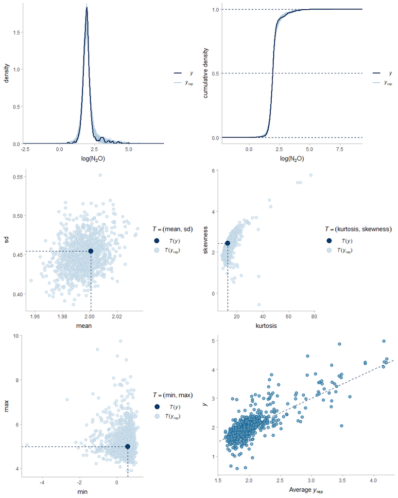

This same checks for the 2nd visit sites is below.

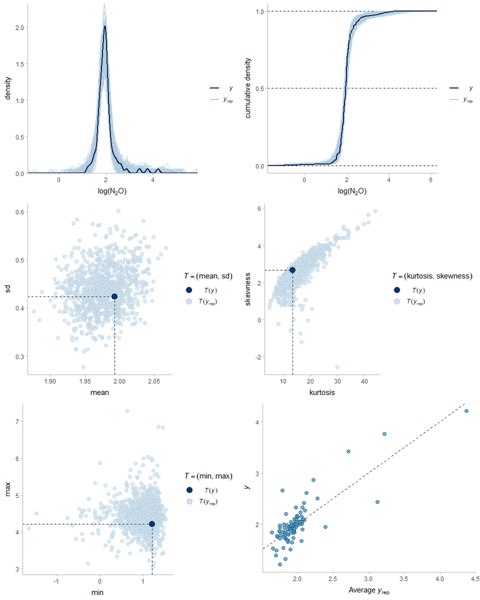

#### 3.4.2.2 Equilibrium N2O

This component of the model also seemed to be an improvement over model 3, with better representation in the tails as indicated in the skewness *vs.* kurtosis PPC.

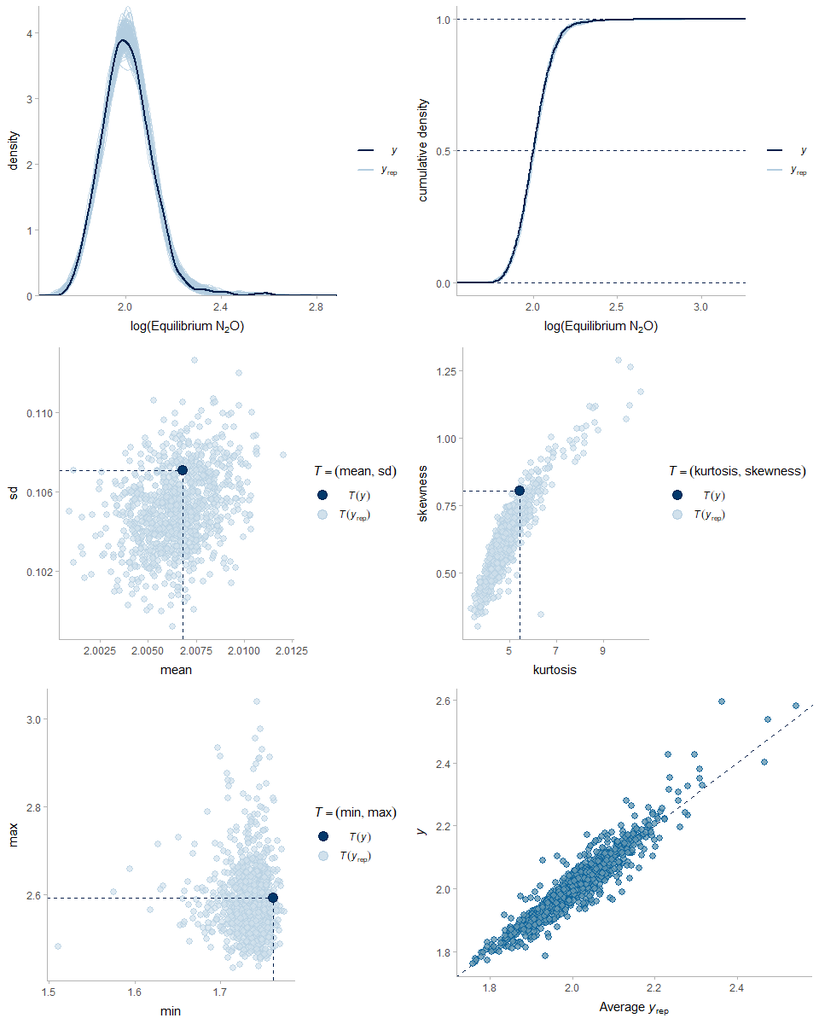

For the 2nd visit sites.

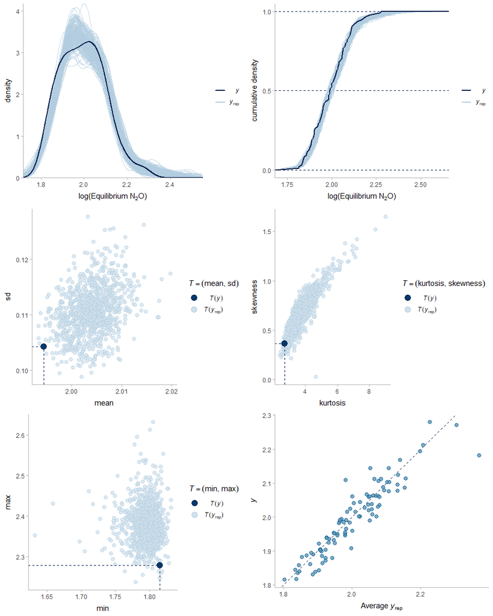

#### 3.4.2.3 Bivariate

Again, an improvement over the previous model with a tighter fit of the PPC to the observed bivariate density.

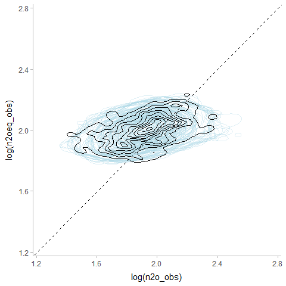

For the 2nd visit sites.

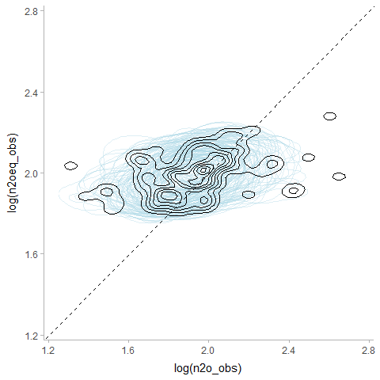

#### 3.4.2.4 Saturation

This check also suggested an improvement over the previous models, with better tail behavior and less bias in the proportion under-saturated measure.

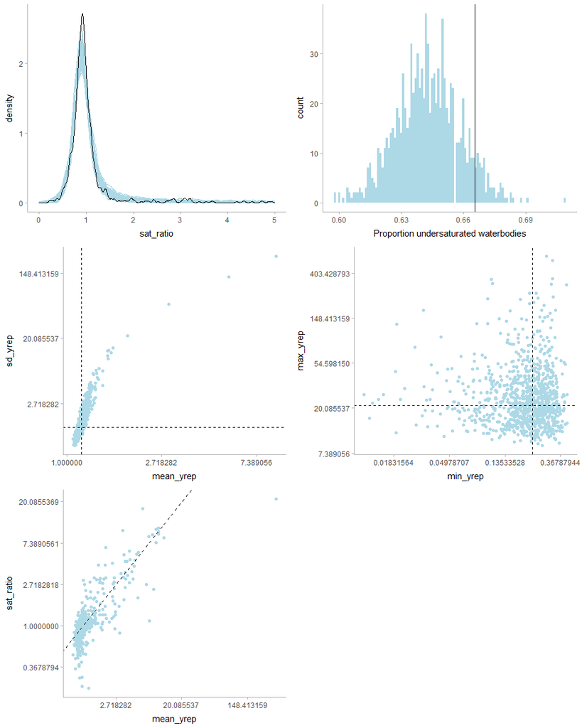

For the second visit sites:

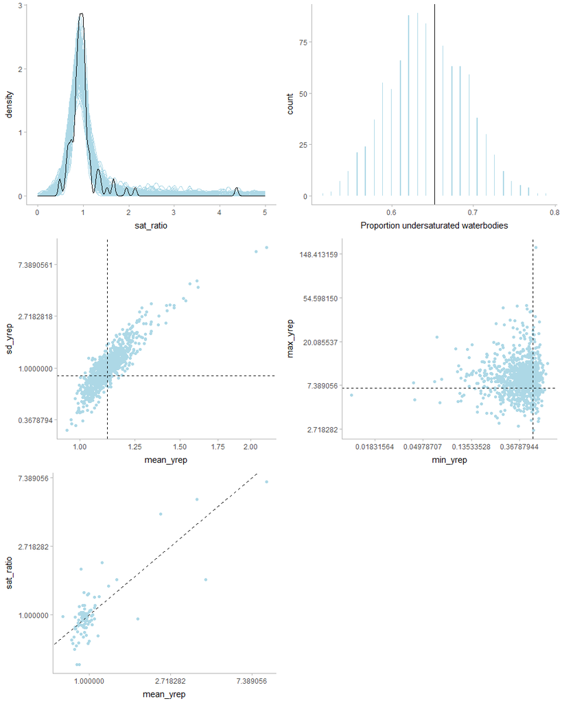

#### 3.4.2.5 R-square

```
##          Estimate Est.Error  Q2.5 Q97.5
## R2logn2o    0.606     0.025 0.551 0.651

##            Estimate Est.Error  Q2.5 Q97.5
## R2logn2oeq    0.875     0.005 0.865 0.883
```

For the 2nd visit data.

```
##          Estimate Est.Error  Q2.5 Q97.5
## R2logn2o    0.661     0.043 0.564 0.731

##            Estimate Est.Error  Q2.5 Q97.5
## R2logn2oeq     0.87     0.007 0.855 0.883
```

### 3.4.3 Covariate effects

#### 3.4.3.1 Dissolved N2O

The conditional effects plots for the covariate effects on dissolved N2O remained similar to the previous model.

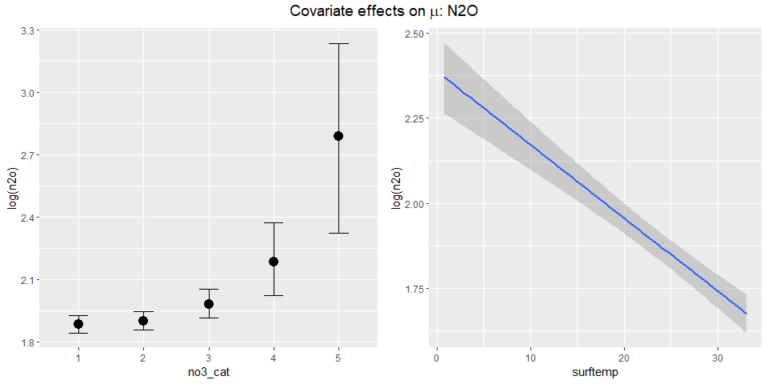

Below are estimates of the conditional effects of the covariates on for N2O. These plots suggested a large effect of NO3 on the variance of N2O, but little to no effect of surface temperature.

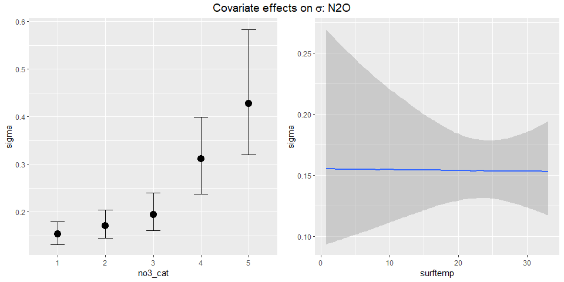

#### 3.4.3.2 Equilibrium N2O

The covariate effects on equilibrium N2O remained largely the same as for the previous model.

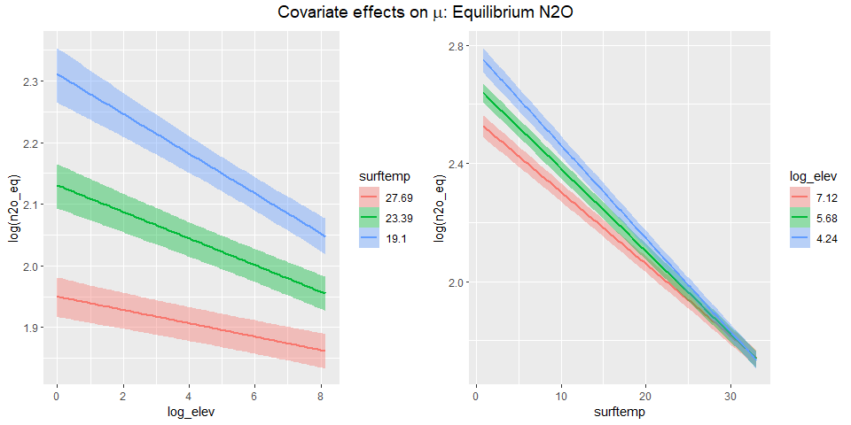

The covariate effects on for N2O-eq suggested a negative effect of surface temperature and litte to no effect of elevation.

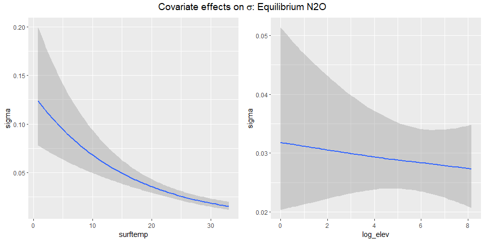

## 3.5 Model 5

In the next model, additional complexity is added to the dissolved N2O component by including a covariate for continuous lake surface area (log scale) as well as interactions between NO3 and log(surface area) and surface temperature. Although some variation due to lake size was likely captured by the categorical survey variable for size in the models above, the categorical distinction may not well represent the true continuous nature of waterbody size and its effects on the response. For example, the largest size category represented all lakes >50 hecatares, which included an extremely wide range of waterbody sizes ranging from 50 to over 300,000 hectares at max. Including the continuous size covariate at the observation level in this manner was expected to do a better job of resolving trends with size. Colinearity between the grouped and observation-level measures were not a major, concern, since the observation-level measure would account for any variation first. Though not presented in this document, violations of the Gauss-Markov assumptions were checked by looking for potential correlations between model errors and the covariates (Bafumi and Gelman 2007).

```r
bf_n2o <- bf(log(n2o) ~ mo(no3_cat) +
               log_area +
               surftemp +
               mo(no3_cat):log_area +
               mo(no3_cat):surftemp +
               (mo(no3_cat) | a | WSA9) +
               (mo(no3_cat) | b | WSA9:state) +
               (1 | c | WSA9:state:size_cat),
             sigma ~ log_area +
               mo(no3_cat) +
               (1 | WSA9) +
               (1 | WSA9:state) +
               (1 | WSA9:state:size_cat),
             family = gaussian())

bf_n2oeq <- bf(log(n2o_eq) ~ surftemp +
                 log_elev +
                 surftemp:log_elev +
                 (1 | a | WSA9) +
                 (1 | b | WSA9:state) +
                 (1 | c | WSA9:state:size_cat),
             sigma ~ surftemp +
               log_elev +
               (1 | WSA9) +
               (1 | WSA9:state) +
               (1 | WSA9:state:size_cat),
             family = gaussian())

priors <- c(
  prior(normal(2, 1), class = "Intercept", resp = "logn2o"),
  prior(normal(0, 1), class = "b", resp = "logn2o"),
  prior(exponential(2), class = "sd", resp = "logn2o"),
  prior(normal(-1, 2), class = "Intercept", dpar = "sigma", resp = "logn2o"),
  prior(normal(0, 1), class = "b", dpar = "sigma", resp = "logn2o"),
  prior(exponential(2), class = "sd", dpar = "sigma", resp = "logn2o"),

  prior(normal(2, 1), class = "Intercept", resp = "logn2oeq"),
  prior(normal(0, 1), class = "b", resp = "logn2oeq"),
  prior(exponential(2), class = "sd", resp = "logn2oeq"),
  prior(normal(-1, 2), class = "Intercept", dpar = "sigma", resp = "logn2oeq"),
  prior(normal(0, 1), class = "b", dpar = "sigma", resp = "logn2oeq"),
  prior(exponential(2), class = "sd", dpar = "sigma", resp = "logn2oeq"),

  prior(lkj(2), class = "rescor"),
  prior(lkj(2), class = "cor")
  )

n2o_mod5 <- brm(bf_n2o +
                  bf_n2oeq +
                  set_rescor(rescor = TRUE),
                data = df_model,
                prior = priors,
  control = list(adapt_delta = 0.975, max_treedepth = 12),
  #sample_prior = "only",
  save_pars = save_pars(all = TRUE),
  seed = 54741,
  chains=4,
  iter=5000,
  cores=4)

save(n2o_mod5, file = "C:/Users/rmartin/OneDrive - Environmental Protection Agency (EPA)/Documents/AE_Reservoirs/DissolvedGasNla/modelFiles/n2o_mod5.rda")
```

### 3.5.1 Summarize fit

Below is a summary of the fitted parameters along with MCMC convergence diagnostics.

```
##  Family: MV(gaussian, gaussian)
##   Links: mu = identity; sigma = log
##          mu = identity; sigma = log
## Formula: log(n2o) ~ mo(no3_cat) + log_area + surftemp + mo(no3_cat):log_area + mo(no3_cat):surftemp + (mo(no3_cat) | a | WSA9) + (mo(no3_cat) | b | WSA9:state) + (1 | c | WSA9:state:size_cat)
##          sigma ~ log_area + mo(no3_cat) + (1 | WSA9) + (1 | WSA9:state) + (1 | WSA9:state:size_cat)
##          log(n2o_eq) ~ surftemp + log_elev + surftemp:log_elev + (1 | a | WSA9) + (1 | b | WSA9:state) + (1 | c | WSA9:state:size_cat)
##          sigma ~ surftemp + log_elev + (1 | WSA9) + (1 | WSA9:state) + (1 | WSA9:state:size_cat)
##    Data: df_model (Number of observations: 984)
##   Draws: 4 chains, each with iter = 5000; warmup = 2500; thin = 1;
##          total post-warmup draws = 10000
##
## Priors:
## b_logn2o ~ normal(0, 1)
## b_logn2o_sigma ~ normal(0, 1)
## b_logn2oeq ~ normal(0, 1)
## b_logn2oeq_sigma ~ normal(0, 1)
## Intercept_logn2o ~ normal(2, 1)
## Intercept_logn2o_sigma ~ normal(-1, 2)
## Intercept_logn2oeq ~ normal(2, 1)
## Intercept_logn2oeq_sigma ~ normal(-1, 2)
## L ~ lkj_corr_cholesky(2)
## Lrescor ~ lkj_corr_cholesky(2)
## <lower=0> sd_logn2o ~ exponential(2)
## <lower=0> sd_logn2o_sigma ~ exponential(2)
## <lower=0> sd_logn2oeq ~ exponential(2)
## <lower=0> sd_logn2oeq_sigma ~ exponential(2)
## simo_logn2o_mono3_cat:log_area1 ~ dirichlet(1)
## simo_logn2o_mono3_cat:surftemp1 ~ dirichlet(1)
## simo_logn2o_mono3_cat1 ~ dirichlet(1)
## simo_logn2o_sigma_mono3_cat1 ~ dirichlet(1)
##
## Multilevel Hyperparameters:
## ~WSA9 (Number of levels: 9)
##                                          Estimate Est.Error l-95% CI u-95% CI
## sd(logn2o_Intercept)                        0.048     0.019    0.020    0.094
## sd(logn2o_mono3_cat)                        0.081     0.050    0.007    0.199
## sd(logn2oeq_Intercept)                      0.034     0.011    0.018    0.062
## sd(sigma_logn2o_Intercept)                  0.111     0.076    0.006    0.293
## sd(sigma_logn2oeq_Intercept)                0.209     0.102    0.036    0.445
## cor(logn2o_Intercept,logn2o_mono3_cat)     -0.056     0.360   -0.713    0.644
```

[output cut: 112 more lines]

```
## logn2o_mono3_cat:surftemp1[4]     2731     2289
## sigma_logn2o_mono3_cat1[1]        6840     4269
## sigma_logn2o_mono3_cat1[2]        7630     5795
## sigma_logn2o_mono3_cat1[3]        6331     6964
## sigma_logn2o_mono3_cat1[4]        4902     5797
##
## Residual Correlations:
##                         Estimate Est.Error l-95% CI u-95% CI  Rhat Bulk_ESS
## rescor(logn2o,logn2oeq)    0.141     0.038    0.066    0.216 1.000    11829
##                         Tail_ESS
## rescor(logn2o,logn2oeq)     8204
##
## Draws were sampled using sampling(NUTS). For each parameter, Bulk_ESS
## and Tail_ESS are effective sample size measures, and Rhat is the potential
## scale reduction factor on split chains (at convergence, Rhat = 1).
```

### 3.5.2 Model checks

Again, the same PPCs as above were performed for this model.

#### 3.5.2.1 Dissolved N2O

The PPC for dissolved N2O below suggested minimal improvements upon the the previous model.

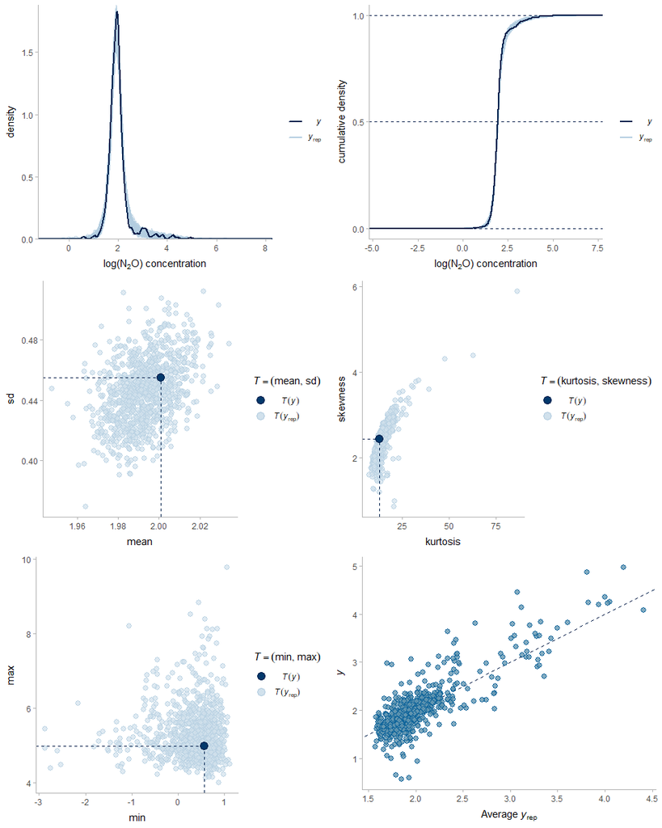

The same check for the 2nd visit data is below.

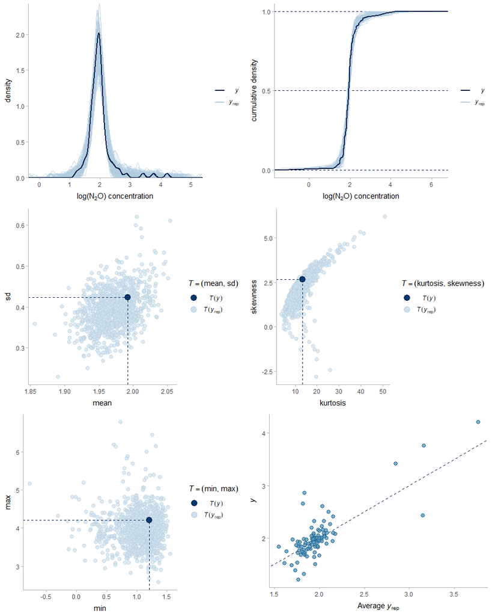

#### 3.5.2.2 Equilibrium N2O

The PPCs for this model were similar to the previous model, which was unsurprising given that it was the same model for N2O-eq.

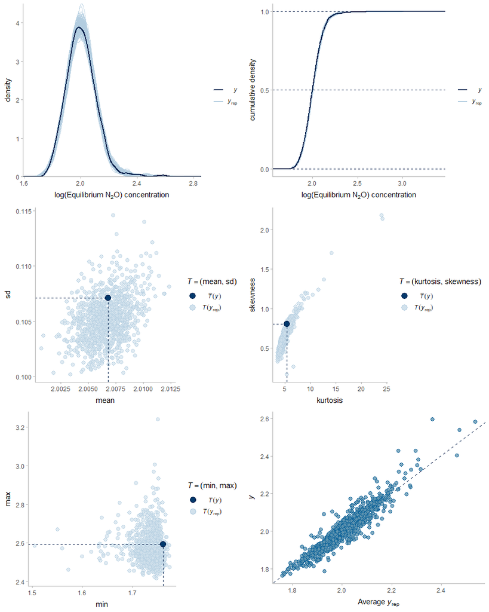

Below, is the same check using the 2nd visit data.

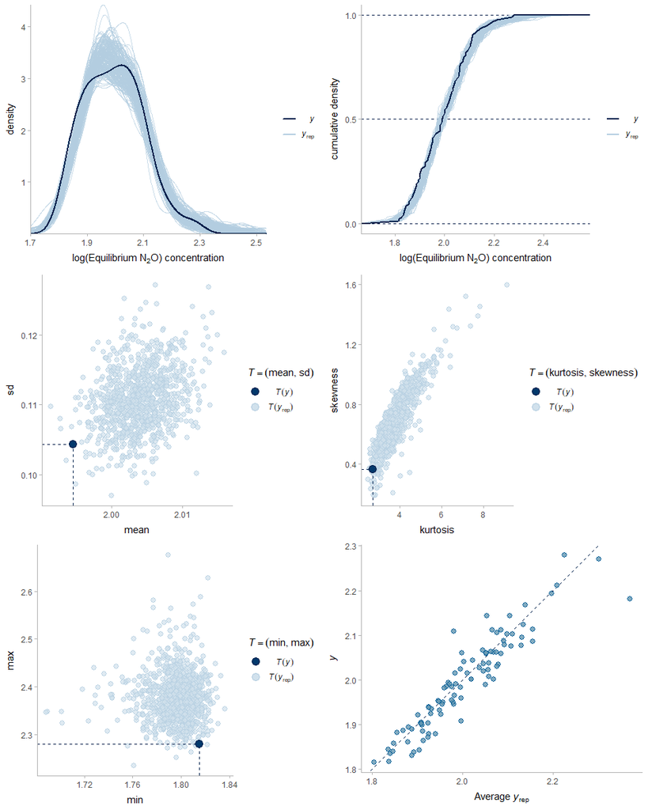

#### 3.5.2.3 Bivariate

This PPC was also similar to the previous model.

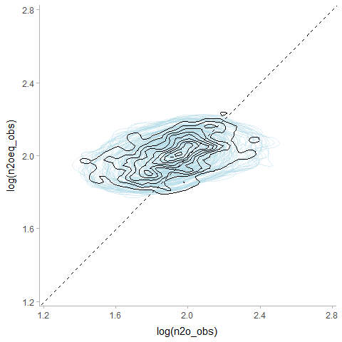

And the check with the 2nd visit data.

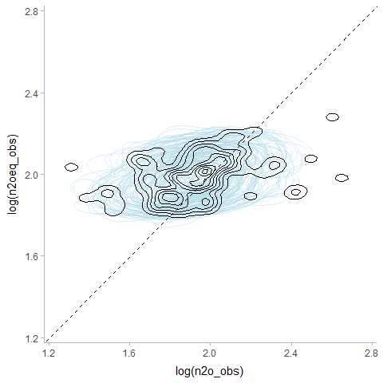

#### 3.5.2.4 Saturation

This check was also similar to the prevoius model, with perhaps slightly less bias in the proportion unsaturated estimates. There was also a potentially concerning extreme prediction in the observed *vs* predicted PPC.

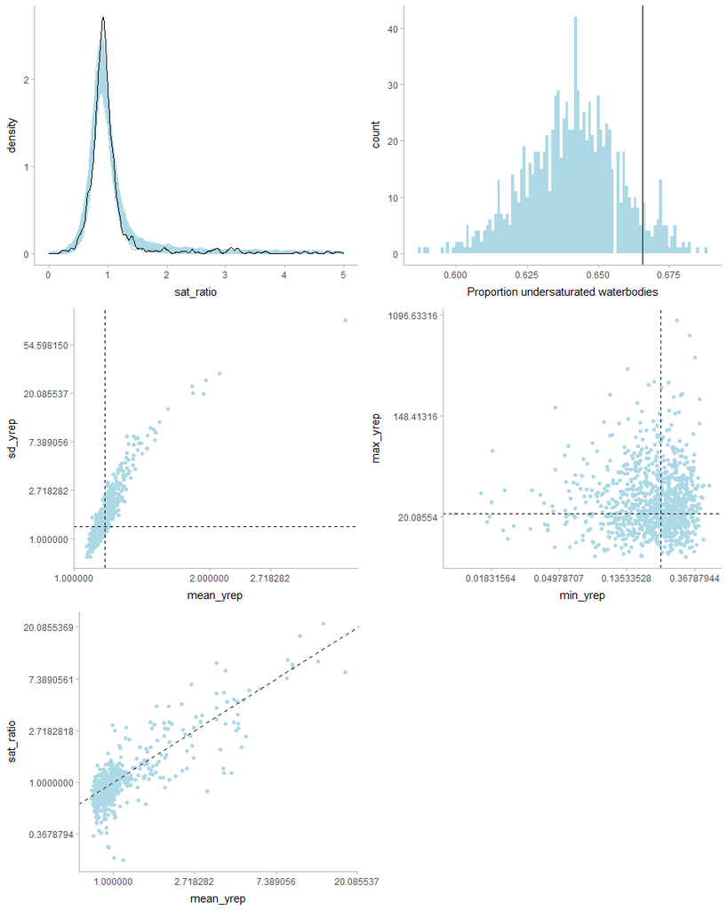

The same check for the revisit sites below:

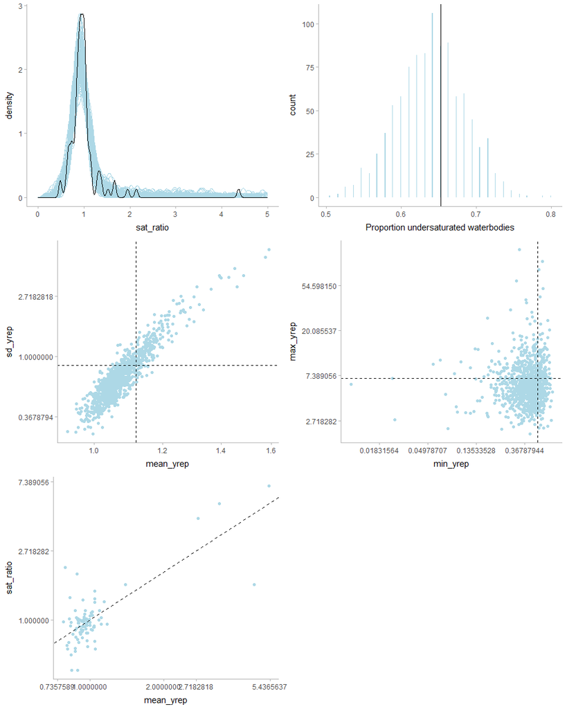

#### 3.5.2.5 R-square

```
##          Estimate Est.Error  Q2.5 Q97.5
## R2logn2o    0.629      0.03 0.563  0.68

##            Estimate Est.Error  Q2.5 Q97.5
## R2logn2oeq    0.874     0.005 0.864 0.882
```

For the revisit sites:

```
##          Estimate Est.Error Q2.5 Q97.5
## R2logn2o    0.573     0.065 0.43 0.684

##            Estimate Est.Error  Q2.5 Q97.5
## R2logn2oeq    0.869     0.007 0.853 0.882
```

### 3.5.3 Covariate effects

#### 3.5.3.1 Dissolved N2O

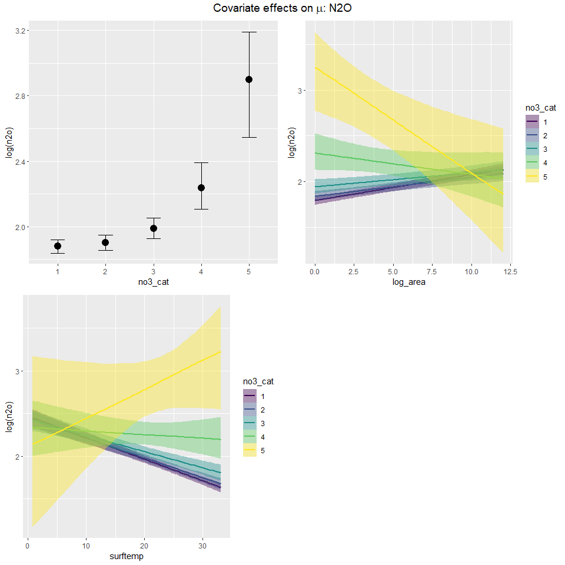

The estimated covariate effects on suggested a negative relationship with log(area) and a positive relationship, again, with NO3.

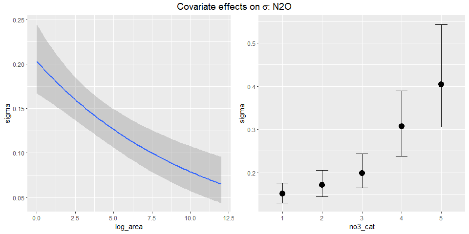

#### 3.5.3.2 Equilibrium N2O

The estimated covariate effects on equilibrium N2O remained largely the same as estimated in the previous model.

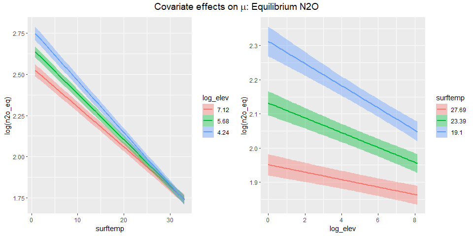

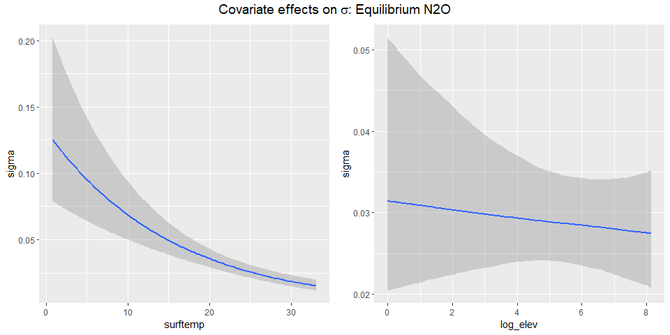

## 3.6 A Final Model

As demonstrated above, models excluding the NO3 covariate consistently resulted in poorer fits to to the observed dissolved N2O data and potentially biased estimates of the saturation ratio. Including surface temperature and elevation in the equilibrium N2O part of the model also resulted in substantially improved replication of key aspects of the observed data. Added flexibility in the distributional terms for both dissolved and equilibrium N2O also led to improvements. To make inferences to the population of interest from a model including these covariates, however, they needed to be (1) fully observed across that population or (2) their missingness needed to be modeled. For the lake area and elevation covariates, data *was* available for all lakes from previously compiled geospatial databases. However, neither surface temperature or NO3 were observed for lakes outside of the sample. Therefore, the final model below included surface temperature and NO3 as additional responses conditioned on the survey design variables and fully observed covariates.

In the final model below, the sub-model for surface temperature assumed a Gamma distributed error distribution and the linear predictor included the survey design variables, latitude, elevation, and Julian date. The shape parameter was also modeled as a function of latitude to address increasing response variance along the latitudinal gradient. The NO3 response was modeled with a cumulative logit likelihood and the linear predictor included all of the survey factors as well as surface temperature and lake area. The dissolved and equilibrium N2O responses were each modeled with Gamma distributed errors, but with the same covariate structure as in model 5. The same structure was also employed for the shape terms in these responses, corresponding to the terms in the previous models. Note that there was no observation-level residual correlation term for this model, since the residuals are undefined for the Gamma and cumulative logit models. Dropping the observation-level residual correlation term was deemed a reasonable compromise that enabled the inclusion of NO3 and surface temperature in the N2O model response. The random intercepts for the group terms, however, still allowed for potential correlations between responses at the group levels.

```r
bf_n2o <- bf(n2o ~ mo(no3_cat) +
               log_area +
               surftemp +
               mo(no3_cat):log_area +
               mo(no3_cat):surftemp +
               (mo(no3_cat) | a | WSA9) +
               (mo(no3_cat) | b | WSA9:state) +
               (1 | c | WSA9:state:size_cat),
             shape ~ log_area +
               mo(no3_cat) +
               (1 | WSA9) +
               (1 | WSA9:state) +
               (1 | WSA9:state:size_cat),
             family = Gamma(link = "log"))

bf_n2oeq <- bf(n2o_eq ~ surftemp +
                 log_elev +
                 surftemp:log_elev +
                 (1 | a | WSA9) +
                 (1 | b | WSA9:state) +
                 (1 | c | WSA9:state:size_cat),
             shape ~ surftemp +
               log_elev +
               (1 | WSA9) +
               (1 | WSA9:state) +
               (1 | WSA9:state:size_cat),
             family = Gamma(link = "log"))

bf_temp <- bf(surftemp ~ lat +
                s(log_elev) +
                s(jdate) +
                (1 | a | WSA9) +
                (1 | b | WSA9:state) +
                (1 | c | WSA9:state:size_cat),
              shape ~ lat,
              family = Gamma(link = "log"))

bf_no3 <- bf(no3_cat ~ surftemp +
               log_area +
               (1 | a | WSA9) +
               (1 | b | WSA9:state) +
               (1 | c | WSA9:state:size_cat),
             family = cumulative(link = "logit", threshold="flexible"))

priors <- c(
  prior(normal(2, 1), class = "Intercept", resp = "n2o"),
  prior(normal(0, 1), class = "b", resp = "n2o"),
  prior(exponential(2), class = "sd", resp = "n2o"),
  prior(normal(5, 4), class = "Intercept", dpar = "shape", resp = "n2o"),
  prior(normal(0, 1), class = "b", dpar = "shape", resp = "n2o"),
  prior(exponential(2), class = "sd", dpar = "shape", resp = "n2o"),

  prior(normal(2, 1), class = "Intercept", resp = "n2oeq"),
  prior(normal(0, 1), class = "b", resp = "n2oeq"),
  prior(exponential(2), class = "sd", resp = "n2oeq"),
  prior(normal(5, 4), class = "Intercept", dpar = "shape", resp = "n2oeq"),
  prior(normal(0, 1), class = "b", dpar = "shape", resp = "n2oeq"),
  prior(exponential(2), class = "sd", dpar = "shape", resp = "n2oeq"),

  prior(normal(3, 1), class = "Intercept", resp = "surftemp"),
  prior(normal(0, 1), class = "b", resp = "surftemp"),
  prior(exponential(0.5), class = "sds", resp = "surftemp"),
  prior(exponential(2), class = "sd", resp = "surftemp"),
  prior(normal(5, 4), class = "Intercept", dpar = "shape", resp = "surftemp"),
  prior(normal(0, 1), class = "b", dpar = "shape", resp = "surftemp"),

  prior(normal(0, 3), class = "Intercept", resp = "no3cat"),
  prior(normal(0, 1), class = "b", resp = "no3cat"),
  prior(exponential(1), class = "sd", resp = "no3cat"),

  prior(lkj(2), class = "cor")
  )

n2o_mod6 <- brm(bf_n2o +
                  bf_n2oeq +
                  bf_temp +
                  bf_no3 +
                  set_rescor(rescor = FALSE),
                data = df_model,
                prior = priors,
  control = list(adapt_delta = 0.975, max_treedepth = 14),
  #sample_prior = "only",
  save_pars = save_pars(all = TRUE),
  seed = 85132,#14548,
  #init = my_inits,
  init_r = 0.5,
  chains=4,
  iter=5000,
  cores=4)

save(n2o_mod6, file = "C:/Users/rmartin/OneDrive - Environmental Protection Agency (EPA)/Documents/AE_Reservoirs/DissolvedGasNla/modelFiles/n2o_mod6.rda")
```

### 3.6.1 Summarize fit

Below is a summary of the fitted parameters and MCMC diagnostics.

```
##  Family: MV(gamma, gamma, gamma, cumulative)
##   Links: mu = log; shape = log
##          mu = log; shape = log
##          mu = log; shape = log
##          mu = logit; disc = identity
## Formula: n2o ~ mo(no3_cat) + log_area + surftemp + mo(no3_cat):log_area + mo(no3_cat):surftemp + (mo(no3_cat) | a | WSA9) + (mo(no3_cat) | b | WSA9:state) + (1 | c | WSA9:state:size_cat)
##          shape ~ log_area + mo(no3_cat) + (1 | WSA9) + (1 | WSA9:state) + (1 | WSA9:state:size_cat)
##          n2o_eq ~ surftemp + log_elev + surftemp:log_elev + (1 | a | WSA9) + (1 | b | WSA9:state) + (1 | c | WSA9:state:size_cat)
##          shape ~ surftemp + log_elev + (1 | WSA9) + (1 | WSA9:state) + (1 | WSA9:state:size_cat)
##          surftemp ~ lat + s(log_elev) + s(jdate) + (1 | a | WSA9) + (1 | b | WSA9:state) + (1 | c | WSA9:state:size_cat)
##          shape ~ lat
##          no3_cat ~ surftemp + log_area + (1 | a | WSA9) + (1 | b | WSA9:state) + (1 | c | WSA9:state:size_cat)
##    Data: df_model (Number of observations: 984)
##   Draws: 4 chains, each with iter = 5000; warmup = 2500; thin = 1;
##          total post-warmup draws = 10000
##
## Priors:
## b_n2o ~ normal(0, 1)
## b_n2o_shape ~ normal(0, 1)
## b_n2oeq ~ normal(0, 1)
## b_n2oeq_shape ~ normal(0, 1)
## b_no3cat ~ normal(0, 1)
## b_surftemp ~ normal(0, 1)
## b_surftemp_shape ~ normal(0, 1)
## Intercept_n2o ~ normal(2, 1)
## Intercept_n2o_shape ~ normal(5, 4)
## Intercept_n2oeq ~ normal(2, 1)
## Intercept_n2oeq_shape ~ normal(5, 4)
## Intercept_no3cat ~ normal(0, 3)
## Intercept_surftemp ~ normal(3, 1)
## Intercept_surftemp_shape ~ normal(5, 4)
## L ~ lkj_corr_cholesky(2)
## <lower=0> sd_n2o ~ exponential(2)
## <lower=0> sd_n2o_shape ~ exponential(2)
## <lower=0> sd_n2oeq ~ exponential(2)
## <lower=0> sd_n2oeq_shape ~ exponential(2)
## <lower=0> sd_no3cat ~ exponential(1)
## <lower=0> sd_surftemp ~ exponential(2)
## <lower=0> sds_surftemp ~ exponential(0.5)
## simo_n2o_mono3_cat:log_area1 ~ dirichlet(1)
```

[output cut: 205 more lines]

```
## n2o_mono3_cat:surftemp1[2]     3213
## n2o_mono3_cat:surftemp1[3]     2971
## n2o_mono3_cat:surftemp1[4]     3106
## shape_n2o_mono3_cat1[1]        4297
## shape_n2o_mono3_cat1[2]        3637
## shape_n2o_mono3_cat1[3]        5848
## shape_n2o_mono3_cat1[4]        4561
##
## Further Distributional Parameters:
##             Estimate Est.Error l-95% CI u-95% CI Rhat Bulk_ESS Tail_ESS
## disc_no3cat    1.000     0.000    1.000    1.000   NA       NA       NA
##
## Draws were sampled using sampling(NUTS). For each parameter, Bulk_ESS
## and Tail_ESS are effective sample size measures, and Rhat is the potential
## scale reduction factor on split chains (at convergence, Rhat = 1).
```

### 3.6.2 Model checks

Below, the same PPCs for dissolved and equilibrium N2O were used as before.

#### 3.6.2.1 Dissolved N2O

The PPCs for dissolved N2O were similar to those for models 4 and 5 above.

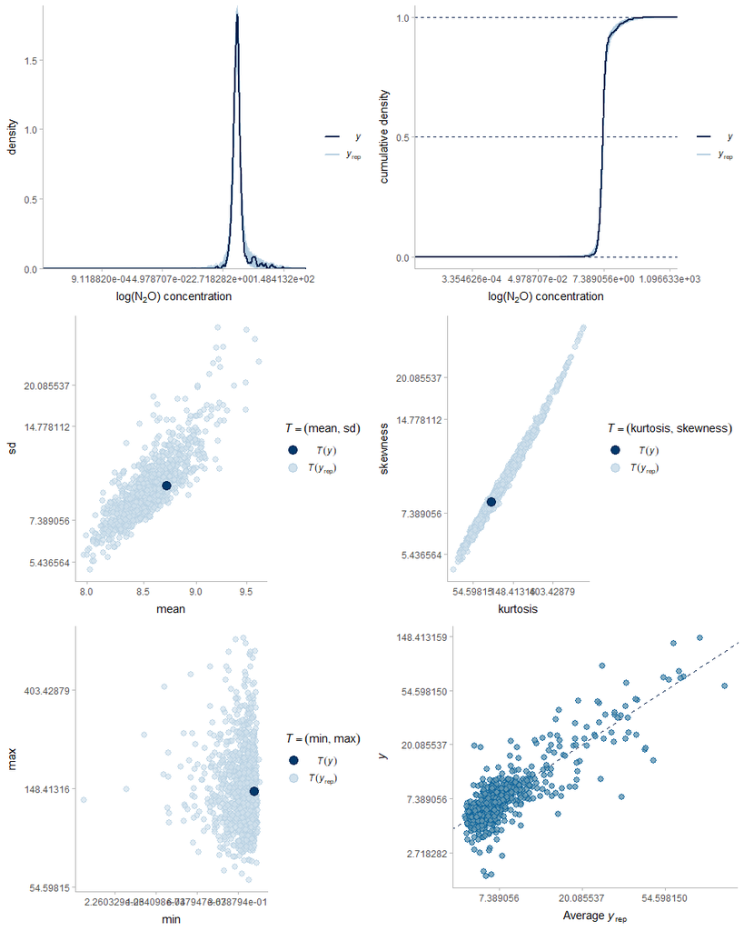

The same check for the re-visit data:

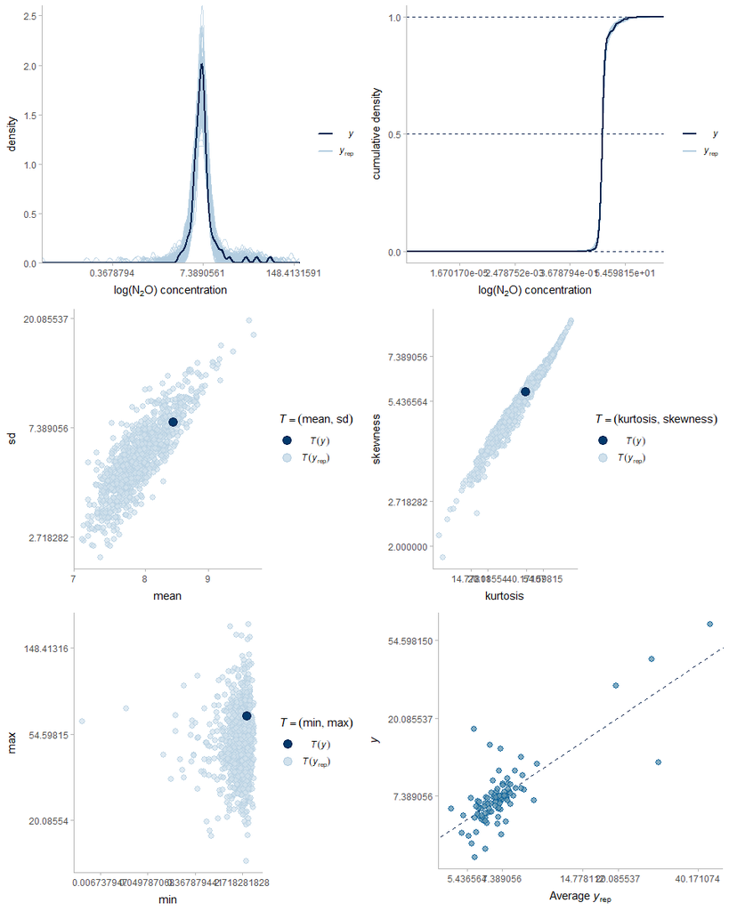

#### 3.6.2.2 Equilibrium N2O

The PPCs for eqilibrium N2O were also similar to the same checks in models 4 and 5.

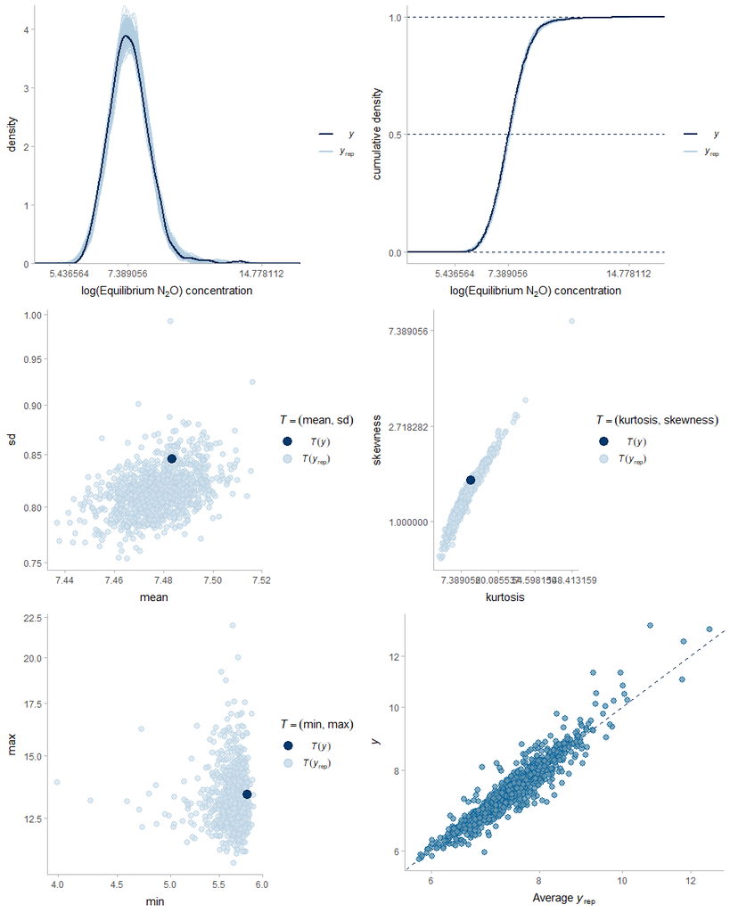

The same check with the re-visit data:

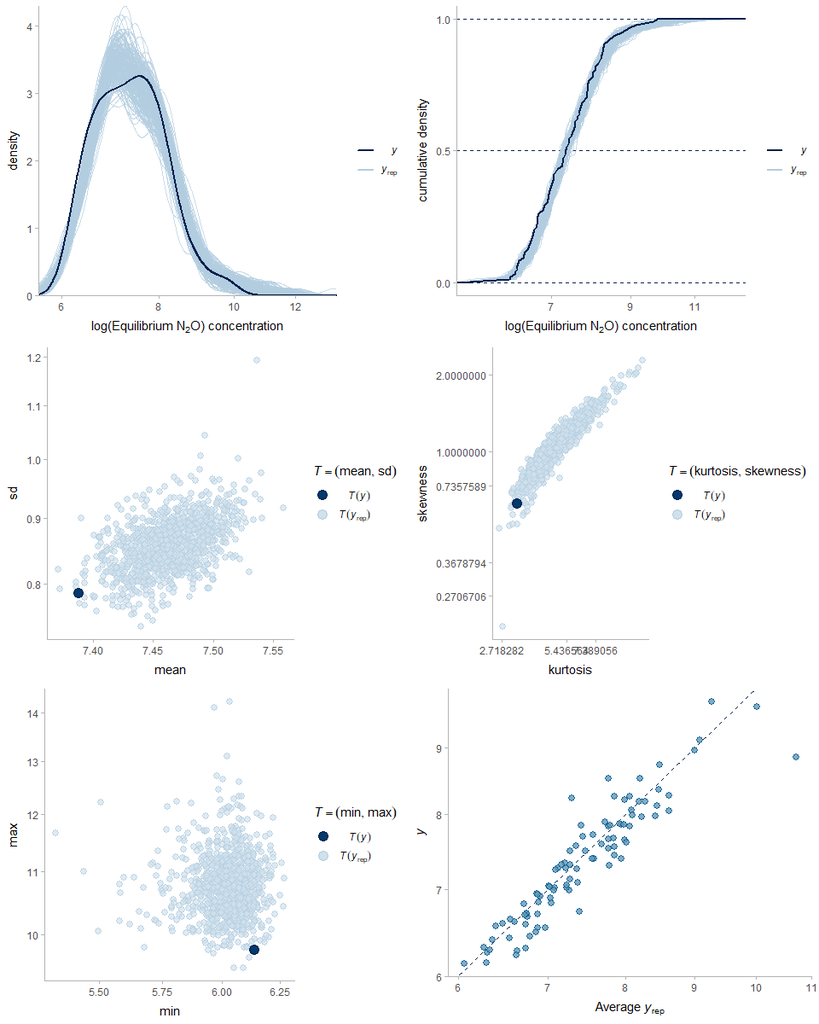

#### 3.6.2.3 Bivariate

This final model provided a reasonable representation of the bivariate relationship between the two N2O responses.

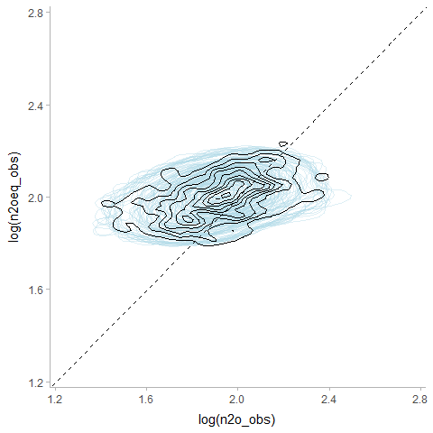

The check with the re-visit data:

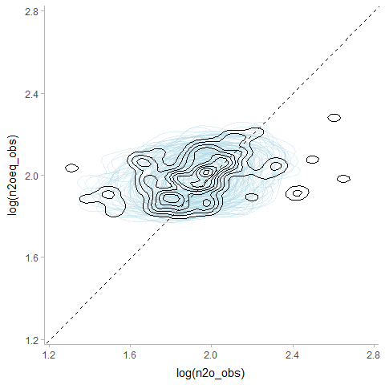

#### 3.6.2.4 Saturation

The saturation ratio PPCs below suggested similar behavior as with models 4 and 5 above, but with perhaps slightly less bias in the predictions for the proportion of undersaturated waterbodies and fewer extreme predictions for the means and standard deviations. The observed *vs.* predicted PPC also appears to have a better behaved variance and no extreme predictions, compared to models 4 and 5.

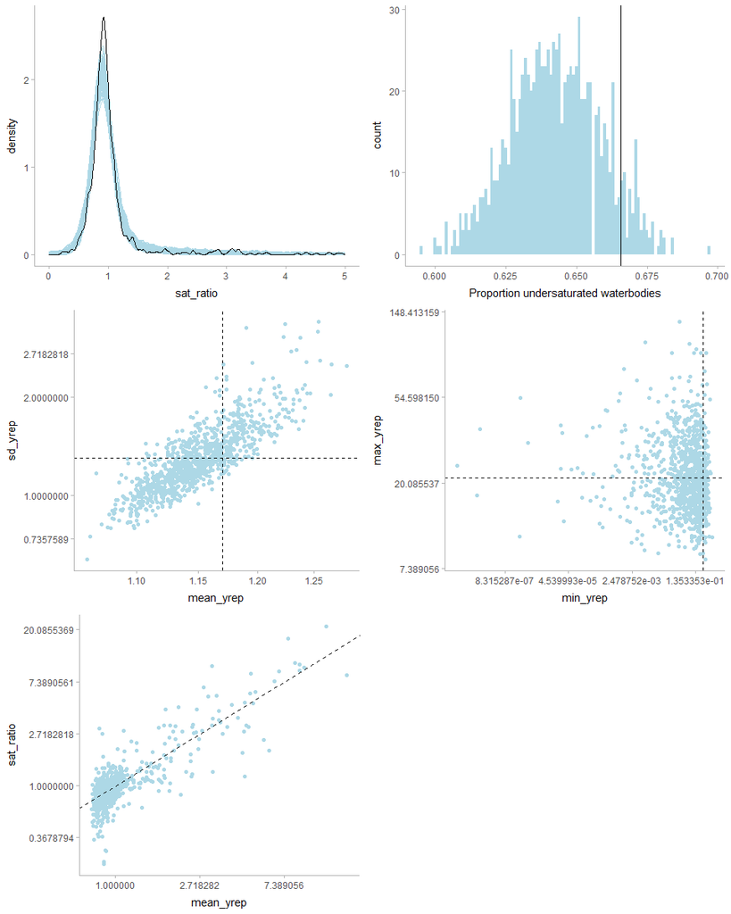

The check for the second-vist data:

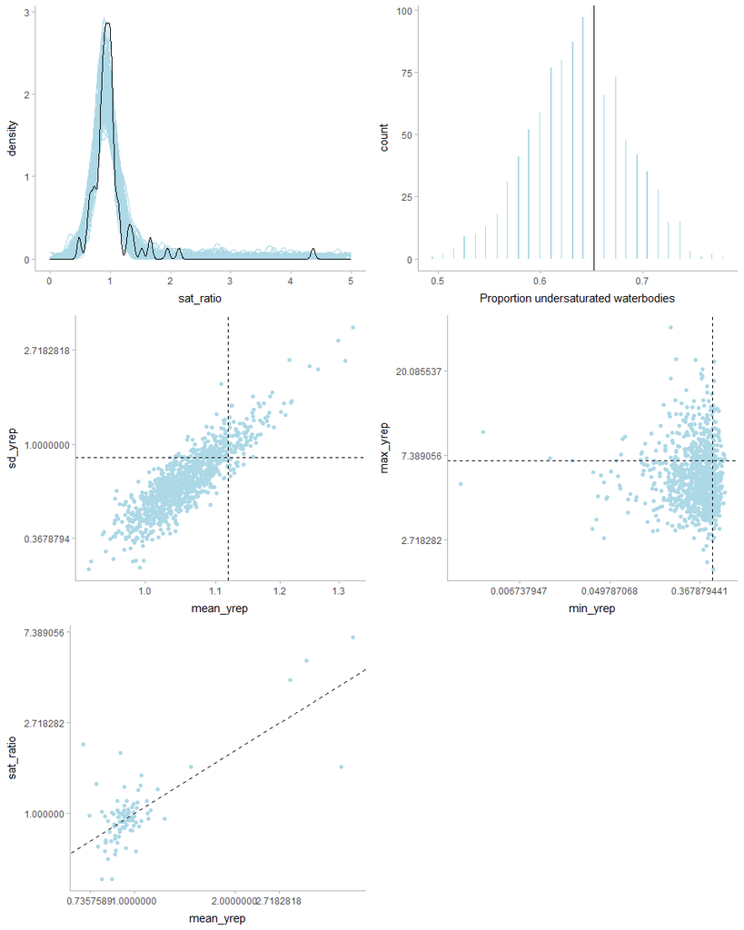

#### 3.6.2.5 R-square

Below are estimates for the Bayesian , which were largely similar for the N2O responses as with models 4 and 5 above. The for the surface temperature response also suggested a good fit.

```
##       Estimate Est.Error  Q2.5 Q97.5
## R2n2o    0.646     0.059 0.503 0.731

##         Estimate Est.Error  Q2.5 Q97.5
## R2n2oeq    0.863     0.006 0.851 0.874

##            Estimate Est.Error  Q2.5 Q97.5
## R2surftemp    0.652     0.036 0.574 0.718
```

Below are the estimates for the second-visit data. That these estimates were similar to those for the data used to fit the model was encouraging and suggested that the model may perform reasonably well out-of-sample.

```
##       Estimate Est.Error  Q2.5 Q97.5
## R2n2o    0.607     0.137 0.325  0.85

##         Estimate Est.Error Q2.5 Q97.5
## R2n2oeq    0.857     0.008 0.84 0.872

##            Estimate Est.Error  Q2.5 Q97.5
## R2surftemp    0.621     0.042 0.535 0.707
```

### 3.6.3 Covariate effects

#### 3.6.3.1 Dissolved N2O

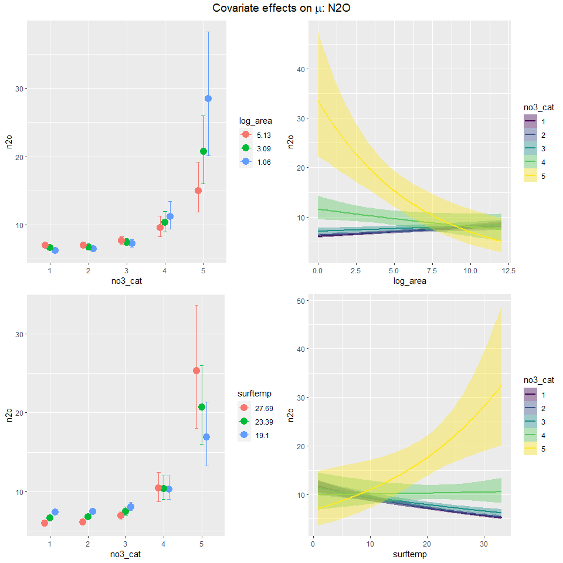

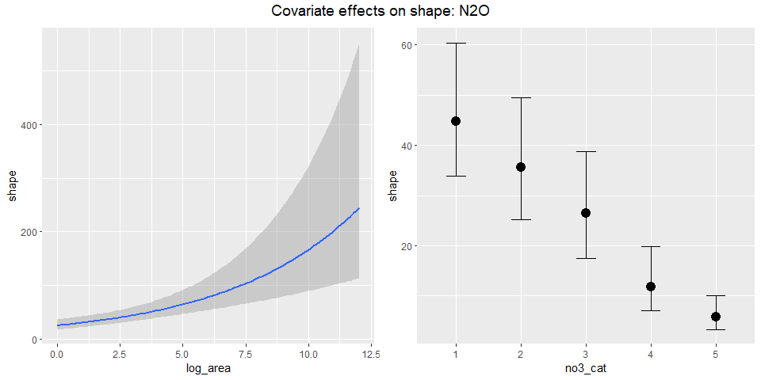

#### 3.6.3.2 Equilibrium N2O

The estimated covariate effects on equilibrium N2O remained largely the same as estimated in the previous model.

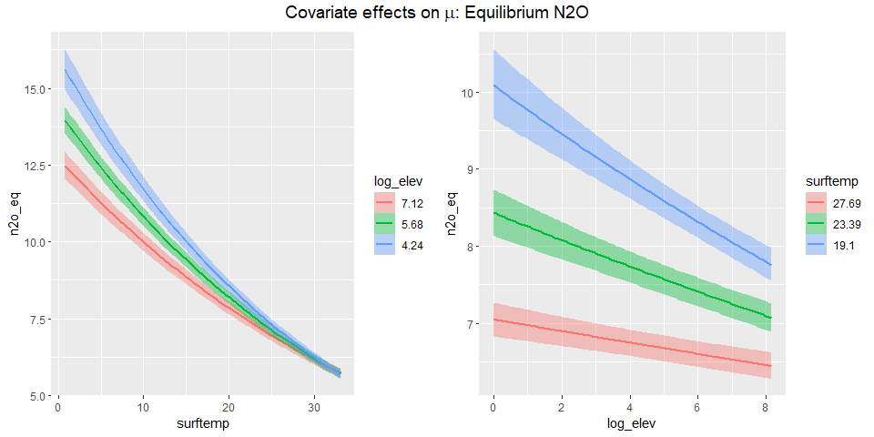

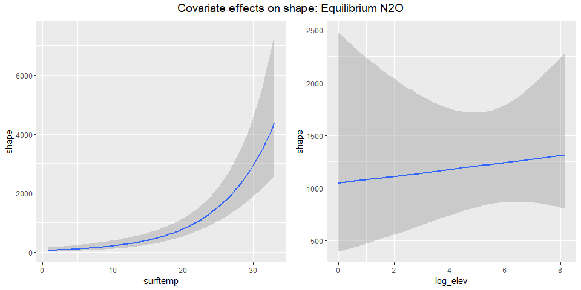

#### 3.6.3.3 Saturation ratio

Below are the estimated conditional effects of the covariates on means for both n2o responses as well as the implied effects on the mean saturation ratio.

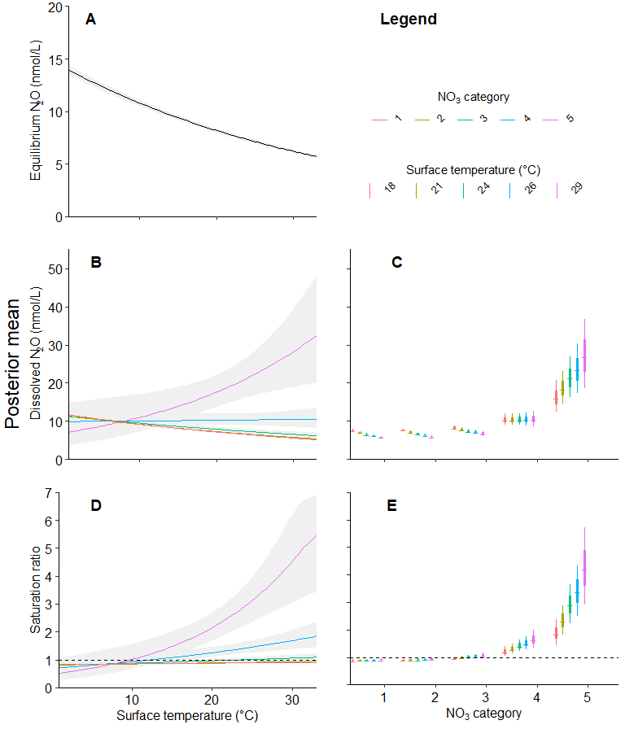

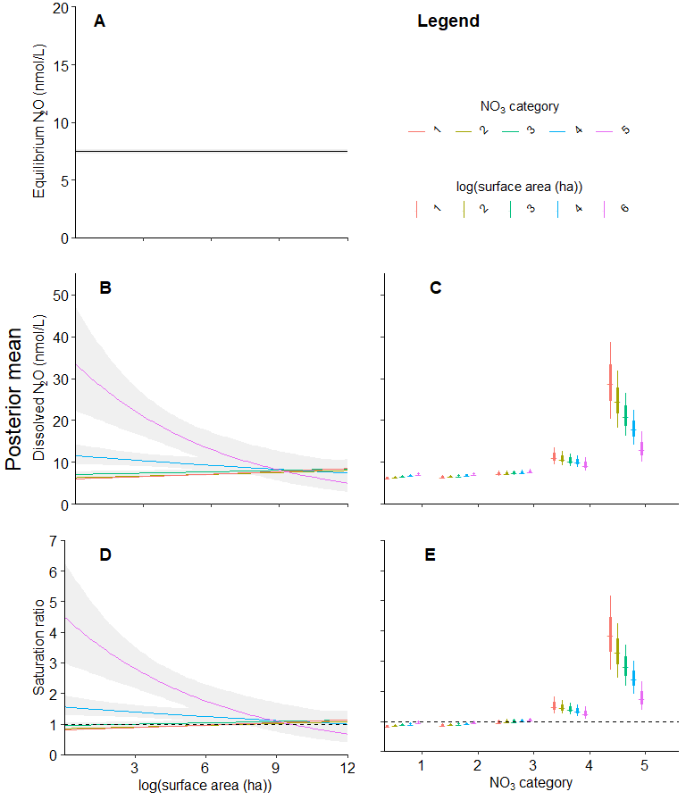

```r
plt_area_effects
```

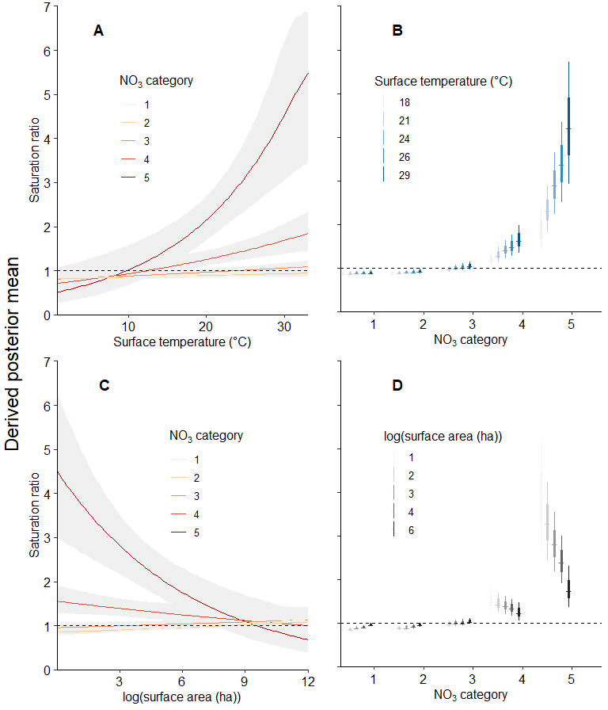

```r
plt_temp_area_effects
```

# 4 Predict to population

As mentioned above, in order to make inferences to the population of interest, the final model above was used to, first, predict surface temperature in the target population, since it depended only on the fully observed covariates. Next, the predictive distribution for surface temperature was used, along with the relevant fully observed covariates, to predict NO3 in the target population. Finally, the predictive distributions for temperature and NO3 were used to predict the N2O responses. The code for these steps is outlined in the following.

The first step used the final model to predict surface temperature to the population:

```r
load("C:/Users/rmartin/OneDrive - Environmental Protection Agency (EPA)/Documents/AE_Reservoirs/DissolvedGasNla/modelFiles/sframe.rda")
load("C:/Users/rmartin/OneDrive - Environmental Protection Agency (EPA)/Documents/AE_Reservoirs/DissolvedGasNla/modelFiles/n2o_mod6.rda")

predict_temp <- sframe %>%
  mutate(jdate = 205) %>%
  add_predicted_draws(n2o_mod6, resp=c("surftemp"),
                      allow_new_levels = TRUE,
                      cores =1,
                      ndraws = 2000) %>%
  mutate(surftemp = .prediction)

save(predict_temp, file = "C:/Users/rmartin/OneDrive - Environmental Protection Agency (EPA)/Documents/AE_Reservoirs/DissolvedGasNla/modelFiles/predict_temp_b.rda")
```

NO3 was next predicted using the posterior predictions for surface temperature and the other fully observed covariates. Note that only one posterior draw per posterior predictive draw for surface temperature was used in order to reduce excess simulations.

```r
temp_X <- predict_temp %>% # select relevant columns as predictors
  ungroup() %>%
  arrange(.draw) %>%
  select(.row, .draw, WSA9, state, size_cat, log_area, log_elev, surftemp)


rm(predict_temp) # reduce memory
gc()

# set number of cores to use for parallel predictions
# and register the workers
cl <- parallel::makeCluster(25)
doSNOW::registerDoSNOW(cl)

# make a progress bar
pb <- txtProgressBar(max = 2000,
                     style = 3)
progress <- function(n) setTxtProgressBar(pb, n)
opts <- list(progress = progress)

system.time( # approx x hrs with 25 workers & 1 draw from PPD
predict_no3 <- foreach(sub_X = isplitRows(temp_X, chunkSize = 465897),
                       .combine = 'c',
                       .packages = c("brms"),
                       .options.snow = opts
                       ) %dopar% {
                         brms::posterior_predict(n2o_mod6,
                                                 newdata = sub_X,
                                                 resp = "no3cat",
                                                 allow_new_levels = T,
                                                 ndraws = 1,
                                                 cores = 1)
                         }
)

close(pb)
parallel::stopCluster(cl)

save(predict_no3, file = "C:/Users/rmartin/OneDrive - Environmental Protection Agency (EPA)/Documents/AE_Reservoirs/DissolvedGasNla/modelFiles/predict_no3_b.rda")
```

Finally, dissolved and equilibrium N2O were predicted using the surface temperature and NO3 predictions, along with the survey variables and other fully observed covariates.

```r
# re-load the temp predictions into memory
load("C:/Users/rmartin/OneDrive - Environmental Protection Agency (EPA)/Documents/AE_Reservoirs/DissolvedGasNla/modelFiles/predict_temp_b.rda")

# Assemble dataframe containing relevant covariates (known and predicted) for predicting N2O responses.
n2o_X <- predict_temp %>%
  ungroup() %>%
  mutate(no3_cat = predict_no3) %>%
  select(WSA9,
         state,
         size_cat,
         log_area,
         surftemp,
         log_elev,
         no3_cat)

rm(predict_temp, predict_no3) # reduce memory

# set number of cores to use for parallel predictions
# and register the workers
cl <- parallel::makeCluster(25)
doSNOW::registerDoSNOW(cl)

# make a progress bar
pb <- txtProgressBar(max = 2000, style = 3)
progress <- function(n) setTxtProgressBar(pb, n)
opts <- list(progress = progress)

# make predictions in parallel
system.time(
predict_n2o <- foreach(sub_X = isplitRows(n2o_X, chunkSize = 465897),
                 .combine = rbind,
                 .options.snow = opts,
                 .packages = c("brms")) %dopar% {
  apply(posterior_predict(n2o_mod6,
                          newdata = sub_X,
                          resp = c("n2o", "n2oeq"),
                          allow_new_levels = T,
                          ndraws = 1,
                          cores = 1), 3, t)
                   }
)

close(pb)
parallel::stopCluster(cl)

colnames(predict_n2o) <- c("n2o", "n2oeq")

save(predict_n2o, file = "C:/Users/rmartin/OneDrive - Environmental Protection Agency (EPA)/Documents/AE_Reservoirs/DissolvedGasNla/modelFiles/predict_n2o_b.rda")
```

Finally, the predictions for all four partially observed responses were assembled into a new dataframe for use in inference:

```r
load("C:/Users/rmartin/OneDrive - Environmental Protection Agency (EPA)/Documents/AE_Reservoirs/DissolvedGasNla/modelFiles/predict_temp_b.rda")
load("C:/Users/rmartin/OneDrive - Environmental Protection Agency (EPA)/Documents/AE_Reservoirs/DissolvedGasNla/modelFiles/predict_no3_b.rda")
load("C:/Users/rmartin/OneDrive - Environmental Protection Agency (EPA)/Documents/AE_Reservoirs/DissolvedGasNla/modelFiles/predict_n2o_b.rda")

all_predictions <- predict_temp %>%
  ungroup() %>%
  mutate(no3cat = predict_no3) %>%
  bind_cols(predict_n2o) %>%
  mutate(n2osat = n2o / n2oeq, # calculate saturation ratio
         .row = rep(1:465897, each = 500),
         .draw = rep(seq(1,500, 1), 465897)) %>%
  mutate(area_ha = exp(log_area)) %>% # include area on ha scale
  select(WSA9,
         state,
         size_cat,
         area_ha,
         lat,
         lon,
         .row,
         .draw,
         surftemp,
         no3cat,
         n2o,
         n2oeq,
         n2osat)

save(all_predictions, file = "C:/Users/rmartin/OneDrive - Environmental Protection Agency (EPA)/Documents/AE_Reservoirs/DissolvedGasNla/modelFiles/all_predictions_b.rda")
```